# Topic: credit score classification

# INTRODUCTION:

In this case study, we explore the application of machine learning techniques to predict credict scores based on a

comprehensive dataset containing various customer attributes and financial information.

The dataset includes features such as customer demographics, income, loan, details, payment behavior, and credit utilization.

By utilizing this data, we aim to develop a machine learning model capable of accurately predicting credit scores for individuals.

The results of this study can assist financial institutions in automating the credit assessment process and improving lending decisions.

# OBJECTIVE:

The objective is to do apply to python and Exploratory Data Analytics and apply to testing of hypothesis and Machine learning technique to influnce by the in credit score standard or good or poor.

# DataSet Description:

ID: Unique identifier for each entry

Customer_ID: Unique identifier for each customer

Month: Month of the data entry

Name: Name of the customer (missing values present)

Age: Age of the customer

SSN: Social Security Number of the customer

Occupation: Occupation of the customer

Annual_Income: Annual income of the customer

Monthly_Inhand_Salary: Monthly in-hand salary of the customer (missing values present)

Num_Bank_Accounts: Number of bank accounts held by the customer

Num_Credit_Card: Number of credit cards held by the customer

Interest_Rate: Interest rate associated with the customer

Num_of_Loan: Number of loans taken by the customer

Type_of_Loan: Type of loan taken by the customer (missing values present)

Delay_from_due_date: Delay in payment from the due date

Num_of_Delayed_Payment: Number of delayed payments made by the customer (missing values present)

Changed_Credit_Limit: Indicator if the credit limit has changed

Num_Credit_Inquiries: Number of credit inquiries made by the customer

Credit_Mix: Credit mix of the customer

Outstanding_Debt: Outstanding debt of the customer

Credit_Utilization_Ratio: Credit utilization ratio of the customer

Credit_History_Age: Age of credit history for the customer (missing values present)

Payment_of_Min_Amount: Payment behavior of the customer

Total_EMI_per_month: Total EMI (Equated Monthly Installment) paid by the customer

Amount_invested_monthly: Monthly amount invested by the customer (missing values present)

Payment_Behaviour: Payment behavior of the customer

Monthly_Balance: Monthly balance of the customer (missing values present)

Credit_Score: Credit score of the customer

# Target variable

Credit_Score: standard or poor or good

# Requirement:

Basic Libaries:

Numpy: NumPy is a library for the Python programming language, adding support for large, multi-dimensional arrays and matrices, along with a large collection of high-level mathematical functions to operate on these arrays.

Pandas: In computer programming, pandas is a software library written for the Python programming language for data manipulation and analysis. In particular, it offers data structures and operations for manipulating numerical tables and time series. It is free software released under the three-clause BSD license

Seaborn: Seaborn is a Python data visualization library based on matplotlib. It provides a high-level interface for drawing attractive and informative statistical graphics.

Matplotlib: Matplotlib is a plotting library for the Python programming language and its numerical mathematics extension NumPy. It provides an object-oriented API for embedding plots into applications using general-purpose GUI toolkits.

Machine Learning Libraries: Install scikit-learn, TensorFlow, Keras, or PyTorch.

Data Manipulation and Analysis Libraries: Use pandas and NumPy for data manipulation.

Visualization Libraries: Utilize Matplotlib, Seaborn, or Plotly for data visualization.

Data Collection and Cleaning: Learn techniques for collecting and cleaning data

Model Development: Understand algorithms like linear regression, logistic regression, decision trees, etc.

Model Evaluation and Validation: Familiarize yourself with techniques for evaluating and validating models.

Feature Engineering: Learn methods for selecting and engineering features.

# Basic Libaries

```python
import numpy as np
import pandas as pd
import re
import matplotlib.pyplot as plt
import seaborn as sns
import scipy.stats as st
import statsmodels.stats as stm
```

```python
df = pd.read_csv(r"C:\Users\User\OneDrive\Documents\train.csv")
df
```

|  | ID | Customer_ID | Month | Name | Age | SSN | Occupation | Annual_Income | Monthly_Inhand_Salary | Num_Bank_Accounts | ... | Credit_Mix | Outstanding_Debt | Credit_Utilization_Ratio | Credit_History_Age | Payment_of_Min_Amount | Total_EMI_per_month | Amount_invested_monthly | Payment_Behaviour | Monthly_Balance | Credit_Score |
| --- | --- | --- | --- | --- | --- | --- | --- | --- | --- | --- | --- | --- | --- | --- | --- | --- | --- | --- | --- | --- | --- |
| 0 | 0x1602 | CUS_0xd40 | January | Aaron Maashoh | 23 | 821-00-0265 | Scientist | 19114.12 | 1824.843333 | 3 | ... | _ | 809.98 | 26.822620 | 22 Years and 1 Months | No | 49.574949 | 80.41529543900253 | High_spent_Small_value_payments | 312.49408867943663 | Good |
| 1 | 0x1603 | CUS_0xd40 | February | Aaron Maashoh | 23 | 821-00-0265 | Scientist | 19114.12 | NaN | 3 | ... | Good | 809.98 | 31.944960 | NaN | No | 49.574949 | 118.28022162236736 | Low_spent_Large_value_payments | 284.62916249607184 | Good |
| 2 | 0x1604 | CUS_0xd40 | March | Aaron Maashoh | -500 | 821-00-0265 | Scientist | 19114.12 | NaN | 3 | ... | Good | 809.98 | 28.609352 | 22 Years and 3 Months | No | 49.574949 | 81.699521264648 | Low_spent_Medium_value_payments | 331.2098628537912 | Good |
| 3 | 0x1605 | CUS_0xd40 | April | Aaron Maashoh | 23 | 821-00-0265 | Scientist | 19114.12 | NaN | 3 | ... | Good | 809.98 | 31.377862 | 22 Years and 4 Months | No | 49.574949 | 199.4580743910713 | Low_spent_Small_value_payments | 223.45130972736786 | Good |
| 4 | 0x1606 | CUS_0xd40 | May | Aaron Maashoh | 23 | 821-00-0265 | Scientist | 19114.12 | 1824.843333 | 3 | ... | Good | 809.98 | 24.797347 | 22 Years and 5 Months | No | 49.574949 | 41.420153086217326 | High_spent_Medium_value_payments | 341.48923103222177 | Good |
| ... | ... | ... | ... | ... | ... | ... | ... | ... | ... | ... | ... | ... | ... | ... | ... | ... | ... | ... | ... | ... | ... |
| 99995 | 0x25fe9 | CUS_0x942c | April | Nicks | 25 | 078-73-5990 | Mechanic | 39628.99 | 3359.415833 | 4 | ... | _ | 502.38 | 34.663572 | 31 Years and 6 Months | No | 35.104023 | 60.97133255718485 | High_spent_Large_value_payments | 479.866228 | Poor |
| 99996 | 0x25fea | CUS_0x942c | May | Nicks | 25 | 078-73-5990 | Mechanic | 39628.99 | 3359.415833 | 4 | ... | _ | 502.38 | 40.565631 | 31 Years and 7 Months | No | 35.104023 | 54.18595028760385 | High_spent_Medium_value_payments | 496.65161 | Poor |
| 99997 | 0x25feb | CUS_0x942c | June | Nicks | 25 | 078-73-5990 | Mechanic | 39628.99 | 3359.415833 | 4 | ... | Good | 502.38 | 41.255522 | 31 Years and 8 Months | No | 35.104023 | 24.02847744864441 | High_spent_Large_value_payments | 516.809083 | Poor |
| 99998 | 0x25fec | CUS_0x942c | July | Nicks | 25 | 078-73-5990 | Mechanic | 39628.99 | 3359.415833 | 4 | ... | Good | 502.38 | 33.638208 | 31 Years and 9 Months | No | 35.104023 | 251.67258219721603 | Low_spent_Large_value_payments | 319.164979 | Standard |
| 99999 | 0x25fed | CUS_0x942c | August | Nicks | 25 | 078-73-5990 | Mechanic | 39628.99_ | 3359.415833 | 4 | ... | Good | 502.38 | 34.192463 | 31 Years and 10 Months | No | 35.104023 | 167.1638651610451 | !@9#%8 | 393.673696 | Poor |

100000 rows × 28 columns

Insight:

```
Total column 28 and total row 100000
```

# Check the head, shape, data-types of the features

```python
df.shape
```

```
(100000, 28)
```

```python
df.info(),
```

```
<class 'pandas.core.frame.DataFrame'>
RangeIndex: 100000 entries, 0 to 99999
Data columns (total 28 columns):
 #   Column                    Non-Null Count   Dtype
---  ------                    --------------   -----
 0   ID                        100000 non-null  object
 1   Customer_ID               100000 non-null  object
 2   Month                     100000 non-null  object
 3   Name                      90015 non-null   object
 4   Age                       100000 non-null  object
 5   SSN                       100000 non-null  object
 6   Occupation                100000 non-null  object
 7   Annual_Income             100000 non-null  object
 8   Monthly_Inhand_Salary     84998 non-null   float64
 9   Num_Bank_Accounts         100000 non-null  int64
```

[output cut: 20 more lines]

```
(None,)
```

### Check the statistical values of features

```python
 df.describe().T
```

|  | count | mean | std | min | 25% | 50% | 75% | max |
| --- | --- | --- | --- | --- | --- | --- | --- | --- |
| Monthly_Inhand_Salary | 84998.0 | 4194.170850 | 3183.686167 | 303.645417 | 1625.568229 | 3093.745000 | 5957.448333 | 15204.633333 |
| Num_Bank_Accounts | 100000.0 | 17.091280 | 117.404834 | -1.000000 | 3.000000 | 6.000000 | 7.000000 | 1798.000000 |
| Num_Credit_Card | 100000.0 | 22.474430 | 129.057410 | 0.000000 | 4.000000 | 5.000000 | 7.000000 | 1499.000000 |
| Interest_Rate | 100000.0 | 72.466040 | 466.422621 | 1.000000 | 8.000000 | 13.000000 | 20.000000 | 5797.000000 |
| Delay_from_due_date | 100000.0 | 21.068780 | 14.860104 | -5.000000 | 10.000000 | 18.000000 | 28.000000 | 67.000000 |
| Num_Credit_Inquiries | 98035.0 | 27.754251 | 193.177339 | 0.000000 | 3.000000 | 6.000000 | 9.000000 | 2597.000000 |
| Credit_Utilization_Ratio | 100000.0 | 32.285173 | 5.116875 | 20.000000 | 28.052567 | 32.305784 | 36.496663 | 50.000000 |
| Total_EMI_per_month | 100000.0 | 1403.118217 | 8306.041270 | 0.000000 | 30.306660 | 69.249473 | 161.224249 | 82331.000000 |

```python
df.describe(exclude=np.number).T
```

|  | count | unique | top | freq |
| --- | --- | --- | --- | --- |
| ID | 100000 | 100000 | 0x1602 | 1 |
| Customer_ID | 100000 | 12500 | CUS_0xd40 | 8 |
| Month | 100000 | 8 | January | 12500 |
| Name | 90015 | 10139 | Langep | 44 |
| Age | 100000 | 1788 | 38 | 2833 |
| SSN | 100000 | 12501 | #F%$D@*&8 | 5572 |
| Occupation | 100000 | 16 | _______ | 7062 |
| Annual_Income | 100000 | 18940 | 36585.12 | 16 |
| Num_of_Loan | 100000 | 434 | 3 | 14386 |
| Type_of_Loan | 88592 | 6260 | Not Specified | 1408 |
| Num_of_Delayed_Payment | 92998 | 749 | 19 | 5327 |
| Changed_Credit_Limit | 100000 | 4384 | _ | 2091 |
| Credit_Mix | 100000 | 4 | Standard | 36479 |
| Outstanding_Debt | 100000 | 13178 | 1360.45 | 24 |
| Credit_History_Age | 90970 | 404 | 15 Years and 11 Months | 446 |
| Payment_of_Min_Amount | 100000 | 3 | Yes | 52326 |
| Amount_invested_monthly | 95521 | 91049 | __10000__ | 4305 |
| Payment_Behaviour | 100000 | 7 | Low_spent_Small_value_payments | 25513 |
| Monthly_Balance | 98800 | 98792 | __-333333333333333333333333333__ | 9 |
| Credit_Score | 100000 | 3 | Standard | 53174 |

# Data preprocessing

```python
df.columns
```

```
Index(['ID', 'Customer_ID', 'Month', 'Name', 'Age', 'SSN', 'Occupation',
       'Annual_Income', 'Monthly_Inhand_Salary', 'Num_Bank_Accounts',
       'Num_Credit_Card', 'Interest_Rate', 'Num_of_Loan', 'Type_of_Loan',
       'Delay_from_due_date', 'Num_of_Delayed_Payment', 'Changed_Credit_Limit',
       'Num_Credit_Inquiries', 'Credit_Mix', 'Outstanding_Debt',
       'Credit_Utilization_Ratio', 'Credit_History_Age',
       'Payment_of_Min_Amount', 'Total_EMI_per_month',
       'Amount_invested_monthly', 'Payment_Behaviour', 'Monthly_Balance',
       'Credit_Score'],
      dtype='object')
```

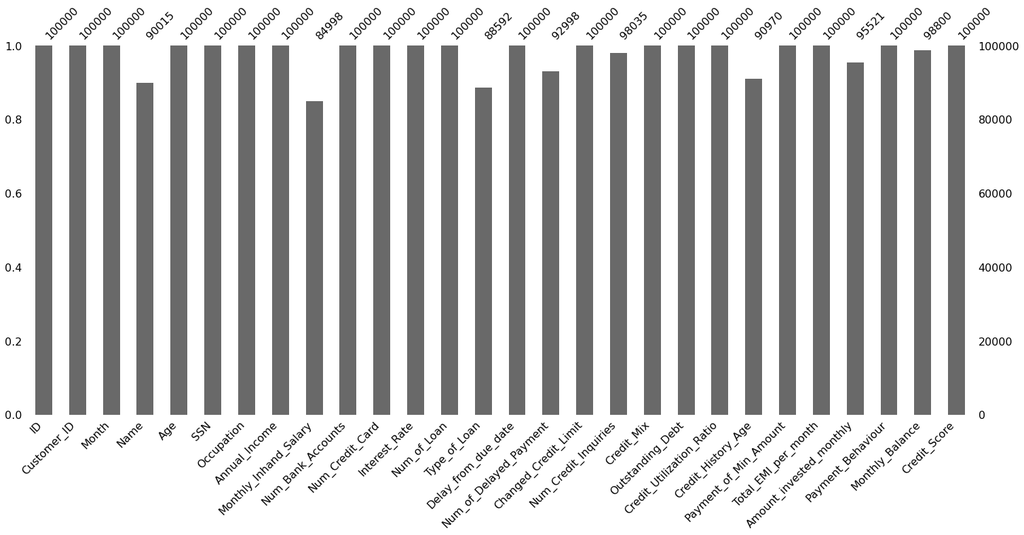

```python
import missingno as ms
ms.bar(df)
```

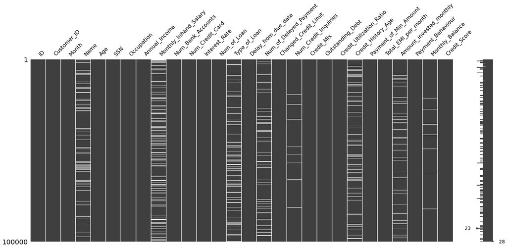

```python
ms.matrix(df)
```

### check the missing values

```python
#check the missing values in target variable
df['Credit_Score'].isnull().sum()
```

```
0
```

```python
df.isnull().sum()
```

```
ID                              0
Customer_ID                     0
Month                           0
Name                         9985
Age                             0
SSN                             0
Occupation                      0
Annual_Income                   0
Monthly_Inhand_Salary       15002
Num_Bank_Accounts               0
Num_Credit_Card                 0
Interest_Rate                   0
Num_of_Loan                     0
Type_of_Loan                11408
Delay_from_due_date             0
Num_of_Delayed_Payment       7002
Changed_Credit_Limit            0
Num_Credit_Inquiries         1965
Credit_Mix                      0
Outstanding_Debt                0
Credit_Utilization_Ratio        0
Credit_History_Age           9030
Payment_of_Min_Amount           0
Total_EMI_per_month             0
Amount_invested_monthly      4479
Payment_Behaviour               0
Monthly_Balance              1200
Credit_Score                    0
dtype: int64
```

Insights of missing value:

```
Eight missing value for this dataset
```

```python
df.isnull().mean()*100
```

```
ID                           0.000
Customer_ID                  0.000
Month                        0.000
Name                         9.985
Age                          0.000
SSN                          0.000
Occupation                   0.000
Annual_Income                0.000
Monthly_Inhand_Salary       15.002
Num_Bank_Accounts            0.000
Num_Credit_Card              0.000
Interest_Rate                0.000
Num_of_Loan                  0.000
Type_of_Loan                11.408
Delay_from_due_date          0.000
Num_of_Delayed_Payment       7.002
Changed_Credit_Limit         0.000
Num_Credit_Inquiries         1.965
Credit_Mix                   0.000
Outstanding_Debt             0.000
Credit_Utilization_Ratio     0.000
Credit_History_Age           9.030
Payment_of_Min_Amount        0.000
Total_EMI_per_month          0.000
Amount_invested_monthly      4.479
Payment_Behaviour            0.000
Monthly_Balance              1.200
Credit_Score                 0.000
dtype: float64
```

# Detect strange values from the NaN Values

```python
object_col = df.describe(include='O').columns
object_col
```

```
Index(['ID', 'Customer_ID', 'Month', 'Name', 'Age', 'SSN', 'Occupation',
       'Annual_Income', 'Num_of_Loan', 'Type_of_Loan',
       'Num_of_Delayed_Payment', 'Changed_Credit_Limit', 'Credit_Mix',
       'Outstanding_Debt', 'Credit_History_Age', 'Payment_of_Min_Amount',
       'Amount_invested_monthly', 'Payment_Behaviour', 'Monthly_Balance',
       'Credit_Score'],
      dtype='object')
```

```python
for col in object_col:
    print('Column Name: '+col)
    print("**"*20)
    print(df[col].value_counts(dropna=False))
    print('END', "--"*18, '\n')
```

```
Column Name: ID
ID
0x1602     1
0x19c88    1
0x19caa    1
0x19ca5    1
0x19ca4    1
          ..
0xd94d     1
0xd94c     1
0xd94b     1
0xd94a     1
0x25fed    1
Name: count, Length: 100000, dtype: int64
END ------------------------------------

Column Name: Customer_ID
Customer_ID
CUS_0xd40     8
CUS_0x9bf4    8
CUS_0x5ae3    8
CUS_0xbe9a    8
CUS_0x4874    8
             ..
CUS_0x2eb4    8
CUS_0x7863    8
CUS_0x9d89    8
CUS_0xc045    8
CUS_0x942c    8
Name: count, Length: 12500, dtype: int64
END ------------------------------------

Column Name: Month
Month
January     12500
February    12500
March       12500
April       12500
May         12500
June        12500
```

[output cut: 239 more lines]

```
366.2890379762706                      1
151.1882696261166                      1
306.75027851710234                     1
278.8720257394474                      1
393.6736955618808                      1
Name: count, Length: 98793, dtype: int64
END ------------------------------------

Column Name: Credit_Score
Credit_Score
Standard    53174
Poor        28998
Good        17828
Name: count, dtype: int64
END ------------------------------------
```

# Fixing a data type (value_counts(), astype(), infer_objects(), convert_dtypes())

```python
df.info()
```

```
<class 'pandas.core.frame.DataFrame'>
RangeIndex: 100000 entries, 0 to 99999
Data columns (total 28 columns):
 #   Column                    Non-Null Count   Dtype
---  ------                    --------------   -----
 0   ID                        100000 non-null  object
 1   Customer_ID               100000 non-null  object
 2   Month                     100000 non-null  object
 3   Name                      90015 non-null   object
 4   Age                       100000 non-null  object
 5   SSN                       100000 non-null  object
 6   Occupation                100000 non-null  object
 7   Annual_Income             100000 non-null  object
 8   Monthly_Inhand_Salary     84998 non-null   float64
 9   Num_Bank_Accounts         100000 non-null  int64
```

[output cut: 20 more lines]

```python
df['ID'] = df.ID.apply(lambda x: int(x, 16))
```

```python
df['Customer_ID'] = df.Customer_ID.apply(lambda x: int(x[4:], 16))
```

```python
df['Month'] = pd.to_datetime(df.Month, format='%B').dt.month
```

```python
# Convert 'Age' column to string type
df['Age'] = df['Age'].astype(str)

# Remove underscore character from 'Age' column
df['Age'] = df['Age'].str.replace('_', '')

# Convert 'Age' column to integers
df['Age'] = df['Age'].astype(int)
```

```python
import numpy as np

df['SSN'] = df['SSN'].apply(lambda x: np.nan if pd.isnull(x) else int(str(x).replace('-', '')) if str(x).replace('-', '').isdigit() else np.nan).astype(float)
```

```python
df['Annual_Income'] = df['Annual_Income'].str.replace('_', '').astype(float)
```

```python
df['Num_of_Loan'] = df['Num_of_Loan'].str.replace('_', '').astype(int)
```

```python
df['Num_of_Delayed_Payment'] = df['Num_of_Delayed_Payment'].str.replace('_', '').astype(float)
```

```python
import numpy as np

df['Changed_Credit_Limit'] = df['Changed_Credit_Limit'].replace(['', '_'], np.nan).astype(float)
```

```python
df['Outstanding_Debt'] = df['Outstanding_Debt'].str.replace('_', '').astype(float)
```

```python
df['Amount_invested_monthly'] = df['Amount_invested_monthly'].str.replace('[^\d.]', '', regex=True).astype(float)
```

```python
df['Monthly_Balance'] = df['Monthly_Balance'].str.replace('[^\d.]', '', regex=True).astype(float)
```

# ##Combining object columns

```python
def Month_Converter(x):
    if pd.notnull(x):
        num1 = int(x.split(' ')[0])
        num2 = int(x.split(' ')[3])

        return (num1*12)+num2
    else:
        return x
```

```python
df['Credit_History_Age'] = df.Credit_History_Age.apply(lambda x: Month_Converter(x)).astype(float)
```

```python
df.groupby('Customer_ID')['Credit_History_Age'].apply(list)
```

```
Customer_ID
1006     [182.0, 183.0, 184.0, 185.0, 186.0, 187.0, 188...
1007     [346.0, 347.0, 348.0, 349.0, 350.0, nan, 352.0...
1008     [292.0, 293.0, 294.0, nan, 296.0, 297.0, 298.0...
1009     [331.0, 332.0, 333.0, 334.0, 335.0, 336.0, 337...
1011     [179.0, 180.0, nan, 182.0, 183.0, 184.0, 185.0...
                               ...
50984    [157.0, 158.0, 159.0, nan, 161.0, 162.0, nan, ...
50990       [70.0, 71.0, 72.0, nan, nan, 75.0, 76.0, 77.0]
50992    [159.0, 160.0, 161.0, 162.0, 163.0, nan, 165.0...
50996    [206.0, 207.0, 208.0, 209.0, 210.0, 211.0, 212...
50999    [226.0, 227.0, 228.0, 229.0, 230.0, 231.0, 232...
Name: Credit_History_Age, Length: 12500, dtype: object
```

```python
df['Type_of_Loan'].value_counts(dropna=False).head(20)
```

```
Type_of_Loan
NaN                                         11408
Not Specified                                1408
Credit-Builder Loan                          1280
Personal Loan                                1272
Debt Consolidation Loan                      1264
Student Loan                                 1240
Payday Loan                                  1200
Mortgage Loan                                1176
Auto Loan                                    1152
Home Equity Loan                             1136
Personal Loan, and Student Loan               320
Not Specified, and Payday Loan                272
Mortgage Loan, and Home Equity Loan           264
Student Loan, and Payday Loan                 256
Student Loan, and Credit-Builder Loan         248
Credit-Builder Loan, and Not Specified        248
Payday Loan, and Debt Consolidation Loan      240
Payday Loan, and Auto Loan                    240
Mortgage Loan, and Not Specified              232
Payday Loan, and Personal Loan                232
Name: count, dtype: int64
```

```python
df['Type_of_Loan'] = df['Type_of_Loan'].apply(lambda x: x.lower().replace('and ', '').replace(', ', ',').strip() if pd.notna(x) else x)
```

```python
df.groupby('Customer_ID')['Type_of_Loan'].value_counts(dropna=False)
```

```
Customer_ID  Type_of_Loan
1006         credit-builder loan,payday loan                                                                 8
1007         home equity loan,mortgage loan,student loan                                                     8
1008         NaN                                                                                             8
1009         credit-builder loan,student loan,not specified,student loan                                     8
1011         personal loan,auto loan,auto loan                                                               8
                                                                                                            ..
50984        home equity loan,mortgage loan,payday loan,mortgage loan,mortgage loan,payday loan              8
50990        mortgage loan,auto loan,auto loan                                                               8
50992        student loan,credit-builder loan,mortgage loan,payday loan,home equity loan,home equity loan    8
50996        NaN                                                                                             8
50999        credit-builder loan                                                                             8
Name: count, Length: 12500, dtype: int64
```

```python
df.groupby('Customer_ID')['Type_of_Loan'].apply(list)
```

```
Customer_ID
1006     [credit-builder loan,payday loan, credit-build...
1007     [home equity loan,mortgage loan,student loan, ...
1008              [nan, nan, nan, nan, nan, nan, nan, nan]
1009     [credit-builder loan,student loan,not specifie...
1011     [personal loan,auto loan,auto loan, personal l...
                               ...
50984    [home equity loan,mortgage loan,payday loan,mo...
50990    [mortgage loan,auto loan,auto loan, mortgage l...
50992    [student loan,credit-builder loan,mortgage loa...
50996             [nan, nan, nan, nan, nan, nan, nan, nan]
50999    [credit-builder loan, credit-builder loan, cre...
Name: Type_of_Loan, Length: 12500, dtype: object
```

```python
import re
```

```python
def get_Diff_Values_Colum(df_column, diff_value=[], sep=',', replace=''):
    column = df_column.dropna()
    for i in column:
        if sep not in i and i not in diff_value:
            diff_value.append(i)
        else:
            for data in map(lambda x:x.strip(), re.sub(replace, '', i).split(sep)):
                if not data in diff_value:
                    diff_value.append(data)
    return dict(enumerate(sorted(diff_value)))
```

```python
get_Diff_Values_Colum(df['Type_of_Loan'])
```

```
{0: 'auto loan',
 1: 'credit-builder loan',
 2: 'debt consolidation loan',
 3: 'home equity loan',
 4: 'mortgage loan',
 5: 'not specified',
 6: 'payday loan',
 7: 'personal loan',
 8: 'student loan'}
```

# Object Column NaN Values: Reassign Group Mode Values

```python
 import scipy.stats as stats
```

```python
# Reassign and Show Function
def Object_NaN_Values_Reassign_Group_Mode(df, groupby, column, inplace=True):
    # Assigning Wrong values Make Simple Function
    def make_NaN_and_fill_mode(df, groupby, column, inplace=True):
        # Assign None to np.NaN
        if df[column].isin([None]).sum():
            df[column][df[column].isin([None])] = np.NaN

        # fill with local mode
        result = df.groupby(groupby)[column].transform(lambda x: x.fillna(stats.mode(x)[0][0]))

        # inplace
        if inplace:
            df[column]=result
        else:
            return result

    # Run
    if inplace:
        # Before Assigning NaN values
        if df[column].value_counts(dropna=False).index.isna().sum():
            x = df[column].value_counts(dropna=False).loc[[np.NaN]]
            print(f'\nBefore Assigning: {column}:', f'have {x.values[0]} NaN Values', end='\n')

        a = df.groupby(groupby)[column].apply(list)
        print(f'\nBefore Assigning Example {column}:\n', *a.head().values, sep='\n', end='\n')

        # Assigning
        make_NaN_and_fill_mode(df, groupby, column, inplace)

        # After Assigning NaN values
        if df[column].value_counts(dropna=False).index.isna().sum():
            y = df[column].value_counts(dropna=False).loc[[np.NaN]]
            print(f'\nBefore Assigning: {column}:', f'have {y.values[0]} NaN Values', end='\n')

        b = df.groupby(groupby)[column].apply(list)
        print(f'\nAfter Assigning Example {column}:\n', *b.head().values, sep='\n', end='\n')
    else:
        # Show
        return make_NaN_and_fill_mode(df, groupby, column, inplace)
```

```python
df.shape
```

```
(100000, 28)
```

```python
df.info()
```

```
<class 'pandas.core.frame.DataFrame'>
RangeIndex: 100000 entries, 0 to 99999
Data columns (total 28 columns):
 #   Column                    Non-Null Count   Dtype
---  ------                    --------------   -----
 0   ID                        100000 non-null  int64
 1   Customer_ID               100000 non-null  int64
 2   Month                     100000 non-null  int32
 3   Name                      90015 non-null   object
 4   Age                       100000 non-null  int32
 5   SSN                       94428 non-null   float64
 6   Occupation                100000 non-null  object
 7   Annual_Income             100000 non-null  float64
 8   Monthly_Inhand_Salary     84998 non-null   float64
 9   Num_Bank_Accounts         100000 non-null  int64
```

[output cut: 20 more lines]

#### Name

```python
df['Name'].value_counts(dropna=False).head()
```

```
Name
NaN         9985
Stevex        44
Langep        44
Jessicad      39
Vaughanl      39
Name: count, dtype: int64
```

```python
Object_NaN_Values_Reassign_Group_Mode(df, 'Customer_ID', 'Name')
```

```
Before Assigning: Name: have 9985 NaN Values

Before Assigning Example Name:

['Matthias Blamontb', 'Matthias Blamontb', 'Matthias Blamontb', 'Matthias Blamontb', 'Matthias Blamontb', 'Matthias Blamontb', 'Matthias Blamontb', nan]
[nan, 'Soyoung Kimu', 'Soyoung Kimu', 'Soyoung Kimu', 'Soyoung Kimu', nan, nan, 'Soyoung Kimu']
['Koht', 'Koht', 'Koht', 'Koht', 'Koht', 'Koht', 'Koht', nan]
['Edd', 'Edd', 'Edd', 'Edd', 'Edd', 'Edd', 'Edd', 'Edd']
['Terry Wadeu', 'Terry Wadeu', 'Terry Wadeu', 'Terry Wadeu', 'Terry Wadeu', 'Terry Wadeu', 'Terry Wadeu', nan]
```

```
Before Assigning: Name: have 144 NaN Values

After Assigning Example Name:

['Matthias Blamontb', 'Matthias Blamontb', 'Matthias Blamontb', 'Matthias Blamontb', 'Matthias Blamontb', 'Matthias Blamontb', 'Matthias Blamontb', 'Matthias Blamontb']
['Soyoung Kimu', 'Soyoung Kimu', 'Soyoung Kimu', 'Soyoung Kimu', 'Soyoung Kimu', 'Soyoung Kimu', 'Soyoung Kimu', 'Soyoung Kimu']
['Koht', 'Koht', 'Koht', 'Koht', 'Koht', 'Koht', 'Koht', 'Koht']
['Edd', 'Edd', 'Edd', 'Edd', 'Edd', 'Edd', 'Edd', 'Edd']
['Terry Wadeu', 'Terry Wadeu', 'Terry Wadeu', 'Terry Wadeu', 'Terry Wadeu', 'Terry Wadeu', 'Terry Wadeu', 'Terry Wadeu']
```

### Occupation

```python
df['Occupation'].value_counts(dropna=False)
```

```
Occupation
_______          7062
Lawyer           6575
Architect        6355
Engineer         6350
Scientist        6299
Mechanic         6291
Accountant       6271
Developer        6235
Media_Manager    6232
Teacher          6215
Entrepreneur     6174
Doctor           6087
Journalist       6085
Manager          5973
Musician         5911
Writer           5885
Name: count, dtype: int64
```

```python
from collections import Counter

occupation_list_1 = ['Journalist', 'Journalist', 'Journalist', 'Journalist', 'Journalist', '_______', 'Journalist', 'Journalist']
occupation_list_2 = ['Manager', 'Manager', '_______', 'Manager', 'Manager', 'Manager', 'Manager', 'Manager']
occupation_list_3 = ['Developer', 'Developer', 'Developer', 'Developer', 'Developer', 'Developer', 'Developer', 'Developer']
occupation_list_4 = ['Accountant', '_______', 'Accountant', 'Accountant', 'Accountant', 'Accountant', 'Accountant', 'Accountant']
occupation_list_5 = ['Writer', 'Writer', 'Writer', 'Writer', '_______', 'Writer', 'Writer', 'Writer']

# Remove empty dataset
occupation_list_1 = [occ for occ in occupation_list_1 if occ != '_______']
occupation_list_2 = [occ for occ in occupation_list_2 if occ != '_______']
occupation_list_3 = [occ for occ in occupation_list_3 if occ != '_______']
occupation_list_4 = [occ for occ in occupation_list_4 if occ != '_______']
occupation_list_5 = [occ for occ in occupation_list_5 if occ != '_______']

# Get value counts
value_counts_1 = dict(Counter(occupation_list_1))
value_counts_2 = dict(Counter(occupation_list_2))
value_counts_3 = dict(Counter(occupation_list_3))
value_counts_4 = dict(Counter(occupation_list_4))
value_counts_5 = dict(Counter(occupation_list_5))

# Print the value counts
print(value_counts_1)
print(value_counts_2)
print(value_counts_3)
print(value_counts_4)
print(value_counts_5)
```

```
{'Journalist': 7}
{'Manager': 7}
{'Developer': 8}
{'Accountant': 7}
{'Writer': 7}
```

### Type_of_Loan

```python
df.groupby('Customer_ID')['Type_of_Loan'].value_counts(dropna=False)
```

```
Customer_ID  Type_of_Loan
1006         credit-builder loan,payday loan                                                                 8
1007         home equity loan,mortgage loan,student loan                                                     8
1008         NaN                                                                                             8
1009         credit-builder loan,student loan,not specified,student loan                                     8
1011         personal loan,auto loan,auto loan                                                               8
                                                                                                            ..
50984        home equity loan,mortgage loan,payday loan,mortgage loan,mortgage loan,payday loan              8
50990        mortgage loan,auto loan,auto loan                                                               8
50992        student loan,credit-builder loan,mortgage loan,payday loan,home equity loan,home equity loan    8
50996        NaN                                                                                             8
50999        credit-builder loan                                                                             8
Name: count, Length: 12500, dtype: int64
```

```python
df['Type_of_Loan'].replace([np.NaN], 'No Data', inplace=True)
```

### Credit_Mix

```python
df['Credit_Mix'].value_counts(dropna=False)
```

```
Credit_Mix
Standard    36479
Good        24337
_           20195
Bad         18989
Name: count, dtype: int64
```

```python
Object_NaN_Values_Reassign_Group_Mode(df, 'Customer_ID', 'Credit_Mix')
```

```
Before Assigning Example Credit_Mix:

['Standard', 'Standard', 'Standard', 'Standard', 'Standard', '_', 'Standard', 'Standard']
['_', 'Standard', 'Standard', 'Standard', '_', 'Standard', '_', 'Standard']
['_', 'Standard', 'Standard', '_', 'Standard', 'Standard', 'Standard', 'Standard']
['Standard', '_', 'Standard', 'Standard', 'Standard', 'Standard', 'Standard', 'Standard']
['_', '_', 'Standard', 'Standard', 'Standard', 'Standard', 'Standard', 'Standard']
```

```
After Assigning Example Credit_Mix:

['Standard', 'Standard', 'Standard', 'Standard', 'Standard', '_', 'Standard', 'Standard']
['_', 'Standard', 'Standard', 'Standard', '_', 'Standard', '_', 'Standard']
['_', 'Standard', 'Standard', '_', 'Standard', 'Standard', 'Standard', 'Standard']
['Standard', '_', 'Standard', 'Standard', 'Standard', 'Standard', 'Standard', 'Standard']
['_', '_', 'Standard', 'Standard', 'Standard', 'Standard', 'Standard', 'Standard']
```

### Payment_of_Min_Amount

```python
df['Payment_of_Min_Amount'].value_counts()   # Not required
```

```
Payment_of_Min_Amount
Yes    52326
No     35667
NM     12007
Name: count, dtype: int64
```

### Payment_Behaviour

```python
df['Payment_Behaviour'].value_counts(dropna=False)
```

```
Payment_Behaviour
Low_spent_Small_value_payments      25513
High_spent_Medium_value_payments    17540
Low_spent_Medium_value_payments     13861
High_spent_Large_value_payments     13721
High_spent_Small_value_payments     11340
Low_spent_Large_value_payments      10425
!@9#%8                               7600
Name: count, dtype: int64
```

```python
Object_NaN_Values_Reassign_Group_Mode(df, 'Customer_ID', 'Payment_Behaviour')
```

```
Before Assigning Example Payment_Behaviour:

['High_spent_Medium_value_payments', 'Low_spent_Medium_value_payments', 'Low_spent_Small_value_payments', 'High_spent_Small_value_payments', 'Low_spent_Large_value_payments', '!@9#%8', 'Low_spent_Large_value_payments', 'Low_spent_Small_value_payments']
['High_spent_Medium_value_payments', 'High_spent_Medium_value_payments', 'Low_spent_Small_value_payments', 'High_spent_Medium_value_payments', 'Low_spent_Small_value_payments', '!@9#%8', 'Low_spent_Small_value_payments', 'Low_spent_Small_value_payments']
['High_spent_Small_value_payments', 'Low_spent_Large_value_payments', 'Low_spent_Small_value_payments', 'High_spent_Small_value_payments', 'High_spent_Medium_value_payments', 'High_spent_Small_value_payments', 'Low_spent_Large_value_payments', 'Low_spent_Large_value_payments']
['High_spent_Medium_value_payments', 'High_spent_Large_value_payments', 'High_spent_Medium_value_payments', 'Low_spent_Large_value_payments', 'Low_spent_Medium_value_payments', 'Low_spent_Large_value_payments', '!@9#%8', 'High_spent_Large_value_payments']
['High_spent_Small_value_payments', 'Low_spent_Small_value_payments', 'High_spent_Medium_value_payments', 'Low_spent_Large_value_payments', 'Low_spent_Medium_value_payments', 'Low_spent_Small_value_payments', 'High_spent_Large_value_payments', 'Low_spent_Medium_value_payments']
```

```
After Assigning Example Payment_Behaviour:

['High_spent_Medium_value_payments', 'Low_spent_Medium_value_payments', 'Low_spent_Small_value_payments', 'High_spent_Small_value_payments', 'Low_spent_Large_value_payments', '!@9#%8', 'Low_spent_Large_value_payments', 'Low_spent_Small_value_payments']
['High_spent_Medium_value_payments', 'High_spent_Medium_value_payments', 'Low_spent_Small_value_payments', 'High_spent_Medium_value_payments', 'Low_spent_Small_value_payments', '!@9#%8', 'Low_spent_Small_value_payments', 'Low_spent_Small_value_payments']
['High_spent_Small_value_payments', 'Low_spent_Large_value_payments', 'Low_spent_Small_value_payments', 'High_spent_Small_value_payments', 'High_spent_Medium_value_payments', 'High_spent_Small_value_payments', 'Low_spent_Large_value_payments', 'Low_spent_Large_value_payments']
['High_spent_Medium_value_payments', 'High_spent_Large_value_payments', 'High_spent_Medium_value_payments', 'Low_spent_Large_value_payments', 'Low_spent_Medium_value_payments', 'Low_spent_Large_value_payments', '!@9#%8', 'High_spent_Large_value_payments']
['High_spent_Small_value_payments', 'Low_spent_Small_value_payments', 'High_spent_Medium_value_payments', 'Low_spent_Large_value_payments', 'Low_spent_Medium_value_payments', 'Low_spent_Small_value_payments', 'High_spent_Large_value_payments', 'Low_spent_Medium_value_payments']
```

# Numeric Column NaN Values: Reassign Group Min-Max

```python
df['Customer_ID'].nunique()
```

```
12500
```

```python
# Reassign Wrong Values and Show Function
def Numeric_Wrong_Values_Reassign_Group_Min_Max(df, groupby, column, inplace=True):
    import scipy.stats as stats

    # Identify Wrong values Range
    def get_group_min_max(df, groupby, column):
        cur = df[df[column].notna()].groupby(groupby)[column].apply(list)
        x, y = cur.apply(lambda x: stats.mode(x)).apply([min, max])
        return x[0][0], y[0][0]

    # Assigning Wrong values
    def make_group_NaN_and_fill_mode(df, groupby, column, inplace=True):
        df_dropped = df[df[column].notna()].groupby(groupby)[column].apply(list)
        x, y = df_dropped.apply(lambda x: stats.mode(x)).apply([min, max])
        mini, maxi = x[0][0], y[0][0]

        # assign Wrong Values to NaN
        col = df[column].apply(lambda x: np.NaN if ((x<mini)|(x>maxi)) else x)

        # fill with local mode
        mode_by_group = df.groupby(groupby)[column].transform(lambda x: x.mode()[0] if not x.mode().empty else np.NaN)
        result = col.fillna(mode_by_group)

        # inplace
        if inplace:
            df[column]=result
        else:
            return result


    # Run
    if inplace:
        # Before Assigning NaN values
        if df[column].value_counts(dropna=False).index.isna().sum():
            x = df[column].value_counts(dropna=False).loc[[np.NaN]]
            print(f'\nBefore Assigning: {column}:', f'have {x.values[0]} NaN Values', end='\n')

        print("\nExisting Min, Max Values:", df[column].apply([min, max]), sep='\n', end='\n')
        mini, maxi = get_group_min_max(df, groupby, column)
        print(f"\nGroupby by {groupby}'s Actual min, max Values:", f'min:\t{mini},\nmax:\t{ maxi}', sep='\n', end='\n')

        a = df.groupby(groupby)[column].apply(list)
        print(f'\nBefore Assigning Example {column}:\n', *a.head().values, sep='\n', end='\n')

        # Assigning
        make_group_NaN_and_fill_mode(df, groupby, column, inplace)

        # After Assigning NaN values
        if df[column].value_counts(dropna=False).index.isna().sum():
            y = df[column].value_counts(dropna=False).loc[[np.NaN]]
            print(f'\nBefore Assigning: {column}:', f'have {y.values[0]} NaN Values', end='\n')

        b = df.groupby(groupby)[column].apply(list)
        print(f'\nAfter Assigning Example {column}:\n', *b.head().values, sep='\n', end='\n')
    else:
        # Show
        return make_group_NaN_and_fill_mode(df, groupby, column, inplace)
```

```python
df.describe().columns
```

```
Index(['ID', 'Customer_ID', 'Month', 'Age', 'SSN', 'Annual_Income',
       'Monthly_Inhand_Salary', 'Num_Bank_Accounts', 'Num_Credit_Card',
       'Interest_Rate', 'Num_of_Loan', 'Delay_from_due_date',
       'Num_of_Delayed_Payment', 'Changed_Credit_Limit',
       'Num_Credit_Inquiries', 'Outstanding_Debt', 'Credit_Utilization_Ratio',
       'Credit_History_Age', 'Total_EMI_per_month', 'Amount_invested_monthly',
       'Monthly_Balance'],
      dtype='object')
```

```python
df['ID'].nunique()
```

```
100000
```

### Month

```python
df['Month'].value_counts()
```

```
Month
1    12500
2    12500
3    12500
4    12500
5    12500
6    12500
7    12500
8    12500
Name: count, dtype: int64
```

### Age

```python
Numeric_Wrong_Values_Reassign_Group_Min_Max(df, 'Customer_ID', 'Age')
```

```
Existing Min, Max Values:
min    -500
max    8698
Name: Age, dtype: int64
```

```
Groupby by Customer_ID's Actual min, max Values:
min:	14,
max:	56

Before Assigning Example Age:

[37, 38, 38, 8153, 38, 38, 38, 38]
[48, 48, 48, 48, 48, 48, 48, 48]
[3452, 37, 37, 37, 37, 37, 37, 37]
[22, 22, 22, 22, 22, 22, 22, 23]
[43, 44, 44, 44, 44, 44, 44, 44]
```

```
After Assigning Example Age:

[37.0, 38.0, 38.0, 38.0, 38.0, 38.0, 38.0, 38.0]
[48.0, 48.0, 48.0, 48.0, 48.0, 48.0, 48.0, 48.0]
[37.0, 37.0, 37.0, 37.0, 37.0, 37.0, 37.0, 37.0]
[22.0, 22.0, 22.0, 22.0, 22.0, 22.0, 22.0, 23.0]
[43.0, 44.0, 44.0, 44.0, 44.0, 44.0, 44.0, 44.0]
```

### SSN

```python
df.SSN.value_counts(dropna=False)
```

```
SSN
NaN            5572
78735990.0        8
486783816.0       8
750677525.0       8
903500305.0       8
               ...
856066147.0       4
753722651.0       4
331281921.0       4
604626133.0       4
286449634.0       4
Name: count, Length: 12501, dtype: int64
```

```python
Numeric_Wrong_Values_Reassign_Group_Min_Max(df, 'Customer_ID', 'SSN')
```

```
Before Assigning: SSN: have 5572 NaN Values

Existing Min, Max Values:
min        81349.0
max    999993421.0
Name: SSN, dtype: float64
```

```
Groupby by Customer_ID's Actual min, max Values:
min:	81349.0,
max:	999993421.0

Before Assigning Example SSN:

[354656948.0, 354656948.0, 354656948.0, 354656948.0, 354656948.0, 354656948.0, 354656948.0, 354656948.0]
[964812710.0, 964812710.0, 964812710.0, 964812710.0, 964812710.0, 964812710.0, 964812710.0, 964812710.0]
[802194704.0, nan, 802194704.0, 802194704.0, 802194704.0, 802194704.0, 802194704.0, 802194704.0]
[nan, nan, 891062189.0, 891062189.0, 891062189.0, 891062189.0, 891062189.0, 891062189.0]
[422130011.0, 422130011.0, 422130011.0, 422130011.0, 422130011.0, 422130011.0, 422130011.0, 422130011.0]
```

```
After Assigning Example SSN:

[354656948.0, 354656948.0, 354656948.0, 354656948.0, 354656948.0, 354656948.0, 354656948.0, 354656948.0]
[964812710.0, 964812710.0, 964812710.0, 964812710.0, 964812710.0, 964812710.0, 964812710.0, 964812710.0]
[802194704.0, 802194704.0, 802194704.0, 802194704.0, 802194704.0, 802194704.0, 802194704.0, 802194704.0]
[891062189.0, 891062189.0, 891062189.0, 891062189.0, 891062189.0, 891062189.0, 891062189.0, 891062189.0]
[422130011.0, 422130011.0, 422130011.0, 422130011.0, 422130011.0, 422130011.0, 422130011.0, 422130011.0]
```

### Annual_Income

```python
df.Annual_Income.value_counts(dropna=False)
```

```
Annual_Income
17816.75       16
22434.16       16
40341.16       16
17273.83       16
109945.32      16
               ..
17079092.00     1
1910572.00      1
20179076.00     1
7980216.00      1
8299495.00      1
Name: count, Length: 13487, dtype: int64
```

```python
Numeric_Wrong_Values_Reassign_Group_Min_Max(df, 'Customer_ID', 'Annual_Income')
```

```
Existing Min, Max Values:
min        7005.93
max    24198062.00
Name: Annual_Income, dtype: float64
```

```
Groupby by Customer_ID's Actual min, max Values:
min:	7005.93,
max:	179987.28

Before Assigning Example Annual_Income:

[16756.18, 16756.18, 16756.18, 16756.18, 16756.18, 16756.18, 16756.18, 16756.18]
[21212.91, 21212.91, 21212.91, 21212.91, 21212.91, 21212.91, 21212.91, 21212.91]
[33540.43, 33540.43, 33540.43, 33540.43, 33540.43, 33540.43, 33540.43, 33540.43]
[80983.64, 80983.64, 80983.64, 80983.64, 80983.64, 80983.64, 80983.64, 80983.64]
[104142.56, 104142.56, 104142.56, 104142.56, 104142.56, 104142.56, 104142.56, 104142.56]
```

```
After Assigning Example Annual_Income:

[16756.18, 16756.18, 16756.18, 16756.18, 16756.18, 16756.18, 16756.18, 16756.18]
[21212.91, 21212.91, 21212.91, 21212.91, 21212.91, 21212.91, 21212.91, 21212.91]
[33540.43, 33540.43, 33540.43, 33540.43, 33540.43, 33540.43, 33540.43, 33540.43]
[80983.64, 80983.64, 80983.64, 80983.64, 80983.64, 80983.64, 80983.64, 80983.64]
[104142.56, 104142.56, 104142.56, 104142.56, 104142.56, 104142.56, 104142.56, 104142.56]
```

### Monthly_Inhand_Salary

```python
df.Monthly_Inhand_Salary.value_counts(dropna=False)
```

```
Monthly_Inhand_Salary
NaN            15002
2295.058333       15
6082.187500       15
6769.130000       15
6358.956667       15
               ...
1087.546445        1
3189.212103        1
5640.117744        1
7727.560450        1
2443.654131        1
Name: count, Length: 13236, dtype: int64
```

```python
Numeric_Wrong_Values_Reassign_Group_Min_Max(df, 'Customer_ID', 'Monthly_Inhand_Salary')
```

```
Before Assigning: Monthly_Inhand_Salary: have 15002 NaN Values

Existing Min, Max Values:
min      303.645417
max    15204.633333
Name: Monthly_Inhand_Salary, dtype: float64
```

```
Groupby by Customer_ID's Actual min, max Values:
min:	303.6454166666666,
max:	15204.633333333331

Before Assigning Example Monthly_Inhand_Salary:

[1331.3483333333334, 1331.3483333333334, 1331.3483333333334, 1331.3483333333334, 1331.3483333333334, 1331.3483333333334, 1331.3483333333334, 1331.3483333333334]
[1496.7425, 1496.7425, 1496.7425, 1496.7425, nan, 1496.7425, 1496.7425, 1496.7425]
[2655.035833333333, 2655.035833333333, 2655.035833333333, 2655.035833333333, 2655.035833333333, 2655.035833333333, 2655.035833333333, 2655.035833333333]
[6692.636666666666, 6692.636666666666, 6692.636666666666, 6692.636666666666, 6692.636666666666, 6692.636666666666, 6692.636666666666, 6692.636666666666]
[8433.546666666667, 8433.546666666667, 8433.546666666667, 8433.546666666667, 8433.546666666667, 8433.546666666667, 8433.546666666667, nan]
```

```
After Assigning Example Monthly_Inhand_Salary:

[1331.3483333333334, 1331.3483333333334, 1331.3483333333334, 1331.3483333333334, 1331.3483333333334, 1331.3483333333334, 1331.3483333333334, 1331.3483333333334]
[1496.7425, 1496.7425, 1496.7425, 1496.7425, 1496.7425, 1496.7425, 1496.7425, 1496.7425]
[2655.035833333333, 2655.035833333333, 2655.035833333333, 2655.035833333333, 2655.035833333333, 2655.035833333333, 2655.035833333333, 2655.035833333333]
[6692.636666666666, 6692.636666666666, 6692.636666666666, 6692.636666666666, 6692.636666666666, 6692.636666666666, 6692.636666666666, 6692.636666666666]
[8433.546666666667, 8433.546666666667, 8433.546666666667, 8433.546666666667, 8433.546666666667, 8433.546666666667, 8433.546666666667, 8433.546666666667]
```

### Num_Bank_Accounts

```python
df.Num_Bank_Accounts.value_counts(dropna=False)
```

```
Num_Bank_Accounts
6       13001
7       12823
8       12765
4       12186
5       12118
        ...
1626        1
1470        1
887         1
211         1
697         1
Name: count, Length: 943, dtype: int64
```

```python
Numeric_Wrong_Values_Reassign_Group_Min_Max(df, 'Customer_ID', 'Num_Bank_Accounts')
```

```
Existing Min, Max Values:
min      -1
max    1798
Name: Num_Bank_Accounts, dtype: int64
```

```
Groupby by Customer_ID's Actual min, max Values:
min:	-1,
max:	10

Before Assigning Example Num_Bank_Accounts:

[9, 9, 9, 9, 9, 9, 9, 9]
[3, 3, 3, 1174, 3, 3, 3, 3]
[6, 6, 6, 6, 6, 6, 6, 6]
[6, 6, 6, 6, 6, 6, 6, 6]
[3, 3, 3, 3, 3, 3, 3, 3]
```

```
After Assigning Example Num_Bank_Accounts:

[9.0, 9.0, 9.0, 9.0, 9.0, 9.0, 9.0, 9.0]
[3.0, 3.0, 3.0, 3.0, 3.0, 3.0, 3.0, 3.0]
[6.0, 6.0, 6.0, 6.0, 6.0, 6.0, 6.0, 6.0]
[6.0, 6.0, 6.0, 6.0, 6.0, 6.0, 6.0, 6.0]
[3.0, 3.0, 3.0, 3.0, 3.0, 3.0, 3.0, 3.0]
```

### Num_Credit_Card

```python
df.Num_Credit_Card.value_counts(dropna=False)
```

```
Num_Credit_Card
5       18459
7       16615
6       16559
4       14030
3       13277
        ...
791         1
1118        1
657         1
640         1
679         1
Name: count, Length: 1179, dtype: int64
```

```python
Numeric_Wrong_Values_Reassign_Group_Min_Max(df, 'Customer_ID', 'Num_Credit_Card')
```

```
Existing Min, Max Values:
min       0
max    1499
Name: Num_Credit_Card, dtype: int64
```

```
Groupby by Customer_ID's Actual min, max Values:
min:	0,
max:	11

Before Assigning Example Num_Credit_Card:

[6, 6, 6, 6, 6, 6, 6, 6]
[4, 4, 4, 4, 4, 4, 4, 888]
[3, 3, 3, 3, 3, 3, 3, 3]
[3, 3, 3, 3, 725, 3, 3, 3]
[5, 5, 5, 5, 5, 5, 5, 5]
```

```
After Assigning Example Num_Credit_Card:

[6.0, 6.0, 6.0, 6.0, 6.0, 6.0, 6.0, 6.0]
[4.0, 4.0, 4.0, 4.0, 4.0, 4.0, 4.0, 4.0]
[3.0, 3.0, 3.0, 3.0, 3.0, 3.0, 3.0, 3.0]
[3.0, 3.0, 3.0, 3.0, 3.0, 3.0, 3.0, 3.0]
[5.0, 5.0, 5.0, 5.0, 5.0, 5.0, 5.0, 5.0]
```

### Interest_Rate

```python
df.Interest_Rate.value_counts(dropna=False)
```

```
Interest_Rate
8       5012
5       4979
6       4721
12      4540
10      4540
        ...
4995       1
1899       1
2120       1
5762       1
5729       1
Name: count, Length: 1750, dtype: int64
```

```python
Numeric_Wrong_Values_Reassign_Group_Min_Max(df, 'Customer_ID', 'Interest_Rate')
```

```
Existing Min, Max Values:
min       1
max    5797
Name: Interest_Rate, dtype: int64
```

```
Groupby by Customer_ID's Actual min, max Values:
min:	1,
max:	34

Before Assigning Example Interest_Rate:

[22, 22, 22, 22, 22, 22, 22, 22]
[10, 10, 10, 10, 10, 10, 10, 10]
[17, 17, 17, 17, 17, 17, 17, 17]
[15, 15, 15, 15, 15, 15, 15, 15]
[5, 5, 5, 5, 5, 5, 5, 5]
```

```
After Assigning Example Interest_Rate:

[22.0, 22.0, 22.0, 22.0, 22.0, 22.0, 22.0, 22.0]
[10.0, 10.0, 10.0, 10.0, 10.0, 10.0, 10.0, 10.0]
[17.0, 17.0, 17.0, 17.0, 17.0, 17.0, 17.0, 17.0]
[15.0, 15.0, 15.0, 15.0, 15.0, 15.0, 15.0, 15.0]
[5.0, 5.0, 5.0, 5.0, 5.0, 5.0, 5.0, 5.0]
```

# Num_of_Loan

```python
df.Num_of_Loan.value_counts(dropna=False)
```

```
Num_of_Loan
3       15104
2       15032
4       14743
0       10930
1       10606
        ...
119         1
321         1
1439        1
663         1
966         1
Name: count, Length: 414, dtype: int64
```

```python
Numeric_Wrong_Values_Reassign_Group_Min_Max(df, 'Customer_ID', 'Num_of_Loan')
```

```
Existing Min, Max Values:
min    -100
max    1496
Name: Num_of_Loan, dtype: int64
```

```
Groupby by Customer_ID's Actual min, max Values:
min:	0,
max:	9

Before Assigning Example Num_of_Loan:

[2, 2, 2, 2, 2, 2, 2, 2]
[3, 3, 3, 3, -100, 3, 3, 3]
[0, 0, 0, 0, 0, 0, 0, 0]
[4, 4, 4, 4, 4, 4, 4, 4]
[3, 3, 3, 3, 3, 3, 3, 3]
```

```
After Assigning Example Num_of_Loan:

[2.0, 2.0, 2.0, 2.0, 2.0, 2.0, 2.0, 2.0]
[3.0, 3.0, 3.0, 3.0, 3.0, 3.0, 3.0, 3.0]
[0.0, 0.0, 0.0, 0.0, 0.0, 0.0, 0.0, 0.0]
[4.0, 4.0, 4.0, 4.0, 4.0, 4.0, 4.0, 4.0]
[3.0, 3.0, 3.0, 3.0, 3.0, 3.0, 3.0, 3.0]
```

### Delay_from_due_date

```python
df.Delay_from_due_date.value_counts(dropna=False)
```

```
Delay_from_due_date
 15    3596
 13    3424
 8     3324
 14    3313
 10    3281
       ...
-4       62
 65      56
-5       33
 66      32
 67      22
Name: count, Length: 73, dtype: int64
```

```python
Numeric_Wrong_Values_Reassign_Group_Min_Max(df, 'Customer_ID', 'Delay_from_due_date')
```

```
Existing Min, Max Values:
min    -5
max    67
Name: Delay_from_due_date, dtype: int64
```

```
Groupby by Customer_ID's Actual min, max Values:
min:	-5,
max:	62

Before Assigning Example Delay_from_due_date:

[48, 48, 48, 48, 48, 48, 48, 48]
[19, 19, 19, 19, 19, 19, 19, 16]
[25, 28, 22, 26, 26, 26, 26, 26]
[19, 19, 19, 19, 19, 19, 19, 19]
[15, 15, 20, 16, 20, 20, 20, 24]
```

```
After Assigning Example Delay_from_due_date:

[48.0, 48.0, 48.0, 48.0, 48.0, 48.0, 48.0, 48.0]
[19.0, 19.0, 19.0, 19.0, 19.0, 19.0, 19.0, 16.0]
[25.0, 28.0, 22.0, 26.0, 26.0, 26.0, 26.0, 26.0]
[19.0, 19.0, 19.0, 19.0, 19.0, 19.0, 19.0, 19.0]
[15.0, 15.0, 20.0, 16.0, 20.0, 20.0, 20.0, 24.0]
```

### Num_of_Delayed_Payment

```python
df.Num_of_Delayed_Payment.value_counts(dropna=False)
```

```
Num_of_Delayed_Payment
NaN       7002
19.0      5481
17.0      5412
16.0      5312
10.0      5309
          ...
1534.0       1
3739.0       1
3313.0       1
4191.0       1
2047.0       1
Name: count, Length: 712, dtype: int64
```

```python
Numeric_Wrong_Values_Reassign_Group_Min_Max(df, 'Customer_ID', 'Num_of_Delayed_Payment')
```

```
Before Assigning: Num_of_Delayed_Payment: have 7002 NaN Values

Existing Min, Max Values:
min      -3.0
max    4397.0
Name: Num_of_Delayed_Payment, dtype: float64
```

```
Groupby by Customer_ID's Actual min, max Values:
min:	-2.0,
max:	28.0

Before Assigning Example Num_of_Delayed_Payment:

[10.0, 12.0, 12.0, 13.0, nan, 12.0, 11.0, 12.0]
[19.0, 19.0, 19.0, 19.0, 19.0, 21.0, 20.0, 19.0]
[11.0, 11.0, 11.0, nan, 11.0, nan, 11.0, 13.0]
[18.0, 18.0, 18.0, 18.0, 18.0, nan, 20.0, 18.0]
[17.0, 16.0, 14.0, nan, 17.0, 14.0, 11.0, 14.0]
```

```
After Assigning Example Num_of_Delayed_Payment:

[10.0, 12.0, 12.0, 13.0, 12.0, 12.0, 11.0, 12.0]
[19.0, 19.0, 19.0, 19.0, 19.0, 21.0, 20.0, 19.0]
[11.0, 11.0, 11.0, 11.0, 11.0, 11.0, 11.0, 13.0]
[18.0, 18.0, 18.0, 18.0, 18.0, 18.0, 20.0, 18.0]
[17.0, 16.0, 14.0, 14.0, 17.0, 14.0, 11.0, 14.0]
```

### Changed_Credit_Limit

```python
df.Changed_Credit_Limit.value_counts(dropna=False)
```

```
Changed_Credit_Limit
 NaN      2091
 8.22      133
 11.50     127
 11.32     126
 7.35      121
          ...
-1.84        1
 0.89        1
 28.06       1
 1.56        1
 21.17       1
Name: count, Length: 4384, dtype: int64
```

```python
Numeric_Wrong_Values_Reassign_Group_Min_Max(df, 'Customer_ID', 'Changed_Credit_Limit')
```

```
Before Assigning: Changed_Credit_Limit: have 2091 NaN Values

Existing Min, Max Values:
min    -6.49
max    36.97
Name: Changed_Credit_Limit, dtype: float64
```

```
Groupby by Customer_ID's Actual min, max Values:
min:	-5.01,
max:	29.98

Before Assigning Example Changed_Credit_Limit:

[10.66, 10.66, 10.66, 10.66, 10.66, 10.66, 10.66, 10.66]
[12.13, 5.13, 5.13, 5.13, 5.13, 2.13, 5.13, 5.13]
[14.11, 14.11, 14.11, 14.11, 14.11, 14.11, 14.11, 14.11]
[16.91, 16.91, 16.91, 16.91, 16.91, 16.91, 19.91, 16.91]
[15.28, 15.28, 15.28, 15.28, 19.28, 15.28, 15.28, 15.28]
```

```
After Assigning Example Changed_Credit_Limit:

[10.66, 10.66, 10.66, 10.66, 10.66, 10.66, 10.66, 10.66]
[12.13, 5.13, 5.13, 5.13, 5.13, 2.13, 5.13, 5.13]
[14.11, 14.11, 14.11, 14.11, 14.11, 14.11, 14.11, 14.11]
[16.91, 16.91, 16.91, 16.91, 16.91, 16.91, 19.91, 16.91]
[15.28, 15.28, 15.28, 15.28, 19.28, 15.28, 15.28, 15.28]
```

### Num_Credit_Inquiries

```python
df.Num_Credit_Inquiries.value_counts(dropna=False)
```

```
Num_Credit_Inquiries
4.0       11271
3.0        8890
6.0        8111
7.0        8058
2.0        8028
          ...
1721.0        1
1750.0        1
2397.0        1
621.0         1
74.0          1
Name: count, Length: 1224, dtype: int64
```

```python
Numeric_Wrong_Values_Reassign_Group_Min_Max(df, 'Customer_ID', 'Num_Credit_Inquiries')
```

```
Before Assigning: Num_Credit_Inquiries: have 1965 NaN Values

Existing Min, Max Values:
min       0.0
max    2597.0
Name: Num_Credit_Inquiries, dtype: float64
```

```
Groupby by Customer_ID's Actual min, max Values:
min:	0.0,
max:	17.0

Before Assigning Example Num_Credit_Inquiries:

[nan, 8.0, 8.0, 8.0, 8.0, 8.0, 8.0, 8.0]
[1.0, 1.0, 1.0, 1.0, 1196.0, 1.0, 1.0, 1.0]
[6.0, 10.0, 10.0, 10.0, 10.0, 10.0, 10.0, 10.0]
[7.0, 7.0, 7.0, 7.0, 7.0, 7.0, 7.0, 7.0]
[6.0, 6.0, 6.0, 6.0, 6.0, 6.0, 6.0, 692.0]
```

```
After Assigning Example Num_Credit_Inquiries:

[8.0, 8.0, 8.0, 8.0, 8.0, 8.0, 8.0, 8.0]
[1.0, 1.0, 1.0, 1.0, 1.0, 1.0, 1.0, 1.0]
[6.0, 10.0, 10.0, 10.0, 10.0, 10.0, 10.0, 10.0]
[7.0, 7.0, 7.0, 7.0, 7.0, 7.0, 7.0, 7.0]
[6.0, 6.0, 6.0, 6.0, 6.0, 6.0, 6.0, 6.0]
```

### Outstanding_Debt

```python
df.Outstanding_Debt.value_counts(dropna=False)
```

```
Outstanding_Debt
1109.03    24
1151.70    24
1360.45    24
460.46     24
1058.13    16
           ..
4230.04     8
641.99      8
98.61       8
2614.48     8
502.38      8
Name: count, Length: 12203, dtype: int64
```

```python
Numeric_Wrong_Values_Reassign_Group_Min_Max(df, 'Customer_ID', 'Outstanding_Debt')
```

```
Existing Min, Max Values:
min       0.23
max    4998.07
Name: Outstanding_Debt, dtype: float64
```

```
Groupby by Customer_ID's Actual min, max Values:
min:	0.23,
max:	4998.07

Before Assigning Example Outstanding_Debt:

[1941.73, 1941.73, 1941.73, 1941.73, 1941.73, 1941.73, 1941.73, 1941.73]
[993.15, 993.15, 993.15, 993.15, 993.15, 993.15, 993.15, 993.15]
[1138.97, 1138.97, 1138.97, 1138.97, 1138.97, 1138.97, 1138.97, 1138.97]
[982.44, 982.44, 982.44, 982.44, 982.44, 982.44, 982.44, 982.44]
[1371.8, 1371.8, 1371.8, 1371.8, 1371.8, 1371.8, 1371.8, 1371.8]
```

```
After Assigning Example Outstanding_Debt:

[1941.73, 1941.73, 1941.73, 1941.73, 1941.73, 1941.73, 1941.73, 1941.73]
[993.15, 993.15, 993.15, 993.15, 993.15, 993.15, 993.15, 993.15]
[1138.97, 1138.97, 1138.97, 1138.97, 1138.97, 1138.97, 1138.97, 1138.97]
[982.44, 982.44, 982.44, 982.44, 982.44, 982.44, 982.44, 982.44]
[1371.8, 1371.8, 1371.8, 1371.8, 1371.8, 1371.8, 1371.8, 1371.8]
```

### Credit_Utilization_Ratio

```python
df.Credit_Utilization_Ratio.value_counts(dropna=False)
```

```
Credit_Utilization_Ratio
26.822620    1
28.327949    1
30.016576    1
25.478841    1
33.933755    1
            ..
30.687138    1
38.730069    1
30.017515    1
27.279794    1
34.192463    1
Name: count, Length: 100000, dtype: int64
```

```python
df.Credit_Utilization_Ratio.isnull().sum()
```

```
0
```

### Credit_History_Age

```python
df.Credit_History_Age.value_counts(dropna=False)
```

```
Credit_History_Age
NaN      9030
191.0     446
232.0     445
233.0     444
215.0     443
         ...
3.0        20
2.0        15
403.0      14
404.0      12
1.0         2
Name: count, Length: 405, dtype: int64
```

```python
#df['Credit_History_Age'] = df.groupby('Customer_ID')['Credit_History_Age'].apply(lambda x: x.interpolate().bfill().ffill())
```

```python
df['Customer_ID'] = df['Customer_ID'].astype(int)
df = df.reset_index(drop=True)
df['Credit_History_Age'] = df.groupby('Customer_ID')['Credit_History_Age'].apply(lambda x: x.interpolate().bfill().ffill()).reset_index(drop=True)
```

### Total_EMI_per_month

```python
df.Total_EMI_per_month.value_counts(dropna=False)
```

```
Total_EMI_per_month
0.000000        10613
49.574949           8
73.533361           8
22.960835           8
38.661127           8
                ...
36408.000000        1
23760.000000        1
24612.000000        1
24325.000000        1
58638.000000        1
Name: count, Length: 14950, dtype: int64
```

```python
Numeric_Wrong_Values_Reassign_Group_Min_Max(df, 'Customer_ID', 'Total_EMI_per_month')
```

```
Existing Min, Max Values:
min        0.0
max    82331.0
Name: Total_EMI_per_month, dtype: float64
```

```
Groupby by Customer_ID's Actual min, max Values:
min:	0.0,
max:	1779.1032538262775

Before Assigning Example Total_EMI_per_month:

[27.44208910654816, 27.44208910654816, 27.44208910654816, 27.44208910654816, 27.44208910654816, 27.44208910654816, 27.44208910654816, 32972.0]
[45.74570037068675, 45.74570037068675, 45.74570037068675, 45.74570037068675, 45.74570037068675, 45.74570037068675, 45.74570037068675, 45.74570037068675]
[0.0, 0.0, 0.0, 0.0, 0.0, 0.0, 0.0, 0.0]
[188.45659522353543, 188.45659522353543, 188.45659522353543, 188.45659522353543, 188.45659522353543, 188.45659522353543, 188.45659522353543, 188.45659522353543]
[257.7386460249556, 257.7386460249556, 257.7386460249556, 257.7386460249556, 257.7386460249556, 257.7386460249556, 257.7386460249556, 257.7386460249556]
```

```
After Assigning Example Total_EMI_per_month:

[27.44208910654816, 27.44208910654816, 27.44208910654816, 27.44208910654816, 27.44208910654816, 27.44208910654816, 27.44208910654816, 27.44208910654816]
[45.74570037068675, 45.74570037068675, 45.74570037068675, 45.74570037068675, 45.74570037068675, 45.74570037068675, 45.74570037068675, 45.74570037068675]
[0.0, 0.0, 0.0, 0.0, 0.0, 0.0, 0.0, 0.0]
[188.45659522353543, 188.45659522353543, 188.45659522353543, 188.45659522353543, 188.45659522353543, 188.45659522353543, 188.45659522353543, 188.45659522353543]
[257.7386460249556, 257.7386460249556, 257.7386460249556, 257.7386460249556, 257.7386460249556, 257.7386460249556, 257.7386460249556, 257.7386460249556]
```

### Amount_invested_monthly

```python
df.Amount_invested_monthly.value_counts(dropna=False)
```

```
Amount_invested_monthly
NaN             4479
10000.000000    4305
0.000000         169
36.662351          1
89.738489          1
                ...
36.541909          1
93.451163          1
140.809722         1
38.739377          1
167.163865         1
Name: count, Length: 91050, dtype: int64
```

```python
Numeric_Wrong_Values_Reassign_Group_Min_Max(df, 'Customer_ID', 'Amount_invested_monthly')
```

```
Before Assigning: Amount_invested_monthly: have 4479 NaN Values

Existing Min, Max Values:
min        0.0
max    10000.0
Name: Amount_invested_monthly, dtype: float64
```

```
Groupby by Customer_ID's Actual min, max Values:
min:	0.0,
max:	10000.0

Before Assigning Example Amount_invested_monthly:

[45.30106826949194, 90.07842318605292, 61.73271462991577, 56.4949816634165, 51.726244263612, 60.82828780912217, 95.6486475869488, 66.71824831147686]
[30.373471914127194, 44.31995483866171, nan, 62.81248610216079, 148.30956484525, 10000.0, 59.30896122323683, 118.54244614778156]
[118.8806978910128, nan, 337.1997406214716, 170.8689598433119, 74.1980692925824, 105.4573791889266, 197.85037247610126, 165.20443547590202]
[149.37725143584314, 146.97809602243544, 101.12020124815511, 492.3974911743151, 264.1791118544216, 261.69017894140734, 200.64143588981403, 126.07161584554541]
[292.2127037381353, nan, 187.59489650806347, 275.635709774446, 487.8062062008502, nan, 124.29952362711306, 481.7990883470461]
```

```
After Assigning Example Amount_invested_monthly:

[45.30106826949194, 90.07842318605292, 61.73271462991577, 56.4949816634165, 51.726244263612, 60.82828780912217, 95.6486475869488, 66.71824831147686]
[30.373471914127194, 44.31995483866171, 30.373471914127194, 62.81248610216079, 148.30956484525, 10000.0, 59.30896122323683, 118.54244614778156]
[118.8806978910128, 74.1980692925824, 337.1997406214716, 170.8689598433119, 74.1980692925824, 105.4573791889266, 197.85037247610126, 165.20443547590202]
[149.37725143584314, 146.97809602243544, 101.12020124815511, 492.3974911743151, 264.1791118544216, 261.69017894140734, 200.64143588981403, 126.07161584554541]
[292.2127037381353, 124.29952362711306, 187.59489650806347, 275.635709774446, 487.8062062008502, 124.29952362711306, 124.29952362711306, 481.7990883470461]
```

### Monthly_Balance

```python
df.Monthly_Balance.value_counts(dropna=False)
```

```
Monthly_Balance
NaN             2868
3.333333e+26       9
3.124941e+02       1
6.236711e+02       1
1.921893e+02       1
                ...
3.297982e+02       1
2.186369e+02       1
2.465517e+02       1
3.548036e+02       1
2.146149e+02       1
Name: count, Length: 97125, dtype: int64
```

```python
Numeric_Wrong_Values_Reassign_Group_Min_Max(df, 'Customer_ID', 'Monthly_Balance')
```

```
Before Assigning: Monthly_Balance: have 2868 NaN Values

Existing Min, Max Values:
min    7.759665e-03
max    3.333333e+26
Name: Monthly_Balance, dtype: float64
```

```
Groupby by Customer_ID's Actual min, max Values:
min:	0.007759664775335295,
max:	1183.9306960885192

Before Assigning Example Monthly_Balance:

[310.39167595729333, 295.61432104073225, 333.9600295968694, 309.1977625633686, 323.9664999631732, 334.864456417663, 280.04409663983637, 328.97449591530835]
[323.5550777151861, 309.6085947906515, 265.4874646531188, 291.11606352715245, 245.61898478406326, 239.46481499922072, 334.61958840607645, 275.3861034815317]
[406.62288544232047, 350.39351957834924, 218.30384271186168, 354.63462349002145, 441.30551404075095, 420.04620414440666, 337.6532108572321, 370.2991478574313]
[581.4298200072883, 573.8289754206959, 629.6868701949761, 258.40958026881617, 496.6279595887097, 489.116892501724, 560.1656355533173, 594.7354555975859]
[553.4033169035758, 228.71773015063442, 648.0211241336477, 579.9803108672652, 377.809814440861, nan, 701.3164970145981, 383.81693229466515]
```

```
Before Assigning: Monthly_Balance: have 1696 NaN Values

After Assigning Example Monthly_Balance:

[310.39167595729333, 295.61432104073225, 333.9600295968694, 309.1977625633686, 323.9664999631732, 334.864456417663, 280.04409663983637, 328.97449591530835]
[323.5550777151861, 309.6085947906515, 265.4874646531188, 291.11606352715245, 245.61898478406326, 239.46481499922072, 334.61958840607645, 275.3861034815317]
[406.62288544232047, 350.39351957834924, 218.30384271186168, 354.63462349002145, 441.30551404075095, 420.04620414440666, 337.6532108572321, 370.2991478574313]
[581.4298200072883, 573.8289754206959, 629.6868701949761, 258.40958026881617, 496.6279595887097, 489.116892501724, 560.1656355533173, 594.7354555975859]
[553.4033169035758, 228.71773015063442, 648.0211241336477, 579.9803108672652, 377.809814440861, 228.71773015063442, 701.3164970145981, 383.81693229466515]
```

```python
df
```

|  | ID | Customer_ID | Month | Name | Age | SSN | Occupation | Annual_Income | Monthly_Inhand_Salary | Num_Bank_Accounts | ... | Credit_Mix | Outstanding_Debt | Credit_Utilization_Ratio | Credit_History_Age | Payment_of_Min_Amount | Total_EMI_per_month | Amount_invested_monthly | Payment_Behaviour | Monthly_Balance | Credit_Score |
| --- | --- | --- | --- | --- | --- | --- | --- | --- | --- | --- | --- | --- | --- | --- | --- | --- | --- | --- | --- | --- | --- |
| 0 | 5634 | 3392 | 1 | Aaron Maashoh | 23.0 | 821000265.0 | Scientist | 19114.12 | 1824.843333 | 3.0 | ... | _ | 809.98 | 26.822620 | 182.0 | No | 49.574949 | 80.415295 | High_spent_Small_value_payments | 312.494089 | Good |
| 1 | 5635 | 3392 | 2 | Aaron Maashoh | 23.0 | 821000265.0 | Scientist | 19114.12 | 1824.843333 | 3.0 | ... | Good | 809.98 | 31.944960 | 183.0 | No | 49.574949 | 118.280222 | Low_spent_Large_value_payments | 284.629162 | Good |
| 2 | 5636 | 3392 | 3 | Aaron Maashoh | 23.0 | 821000265.0 | Scientist | 19114.12 | 1824.843333 | 3.0 | ... | Good | 809.98 | 28.609352 | 184.0 | No | 49.574949 | 81.699521 | Low_spent_Medium_value_payments | 331.209863 | Good |
| 3 | 5637 | 3392 | 4 | Aaron Maashoh | 23.0 | 821000265.0 | Scientist | 19114.12 | 1824.843333 | 3.0 | ... | Good | 809.98 | 31.377862 | 185.0 | No | 49.574949 | 199.458074 | Low_spent_Small_value_payments | 223.451310 | Good |
| 4 | 5638 | 3392 | 5 | Aaron Maashoh | 23.0 | 821000265.0 | Scientist | 19114.12 | 1824.843333 | 3.0 | ... | Good | 809.98 | 24.797347 | 186.0 | No | 49.574949 | 41.420153 | High_spent_Medium_value_payments | 341.489231 | Good |
| ... | ... | ... | ... | ... | ... | ... | ... | ... | ... | ... | ... | ... | ... | ... | ... | ... | ... | ... | ... | ... | ... |
| 99995 | 155625 | 37932 | 4 | Nicks | 25.0 | 78735990.0 | Mechanic | 39628.99 | 3359.415833 | 4.0 | ... | _ | 502.38 | 34.663572 | 229.0 | No | 35.104023 | 60.971333 | High_spent_Large_value_payments | NaN | Poor |
| 99996 | 155626 | 37932 | 5 | Nicks | 25.0 | 78735990.0 | Mechanic | 39628.99 | 3359.415833 | 4.0 | ... | _ | 502.38 | 40.565631 | 230.0 | No | 35.104023 | 54.185950 | High_spent_Medium_value_payments | NaN | Poor |
| 99997 | 155627 | 37932 | 6 | Nicks | 25.0 | 78735990.0 | Mechanic | 39628.99 | 3359.415833 | 4.0 | ... | Good | 502.38 | 41.255522 | 231.0 | No | 35.104023 | 24.028477 | High_spent_Large_value_payments | NaN | Poor |
| 99998 | 155628 | 37932 | 7 | Nicks | 25.0 | 78735990.0 | Mechanic | 39628.99 | 3359.415833 | 4.0 | ... | Good | 502.38 | 33.638208 | 232.0 | No | 35.104023 | 251.672582 | Low_spent_Large_value_payments | NaN | Standard |
| 99999 | 155629 | 37932 | 8 | Nicks | 25.0 | 78735990.0 | Mechanic | 39628.99 | 3359.415833 | 4.0 | ... | Good | 502.38 | 34.192463 | 233.0 | No | 35.104023 | 167.163865 | !@9#%8 | NaN | Poor |

100000 rows × 28 columns

```python
print(df['Name'].unique())
df = df[df['Name'] != 'Steven C.z']
df['Name'].fillna('Unknown', inplace=True)
```

```
['Aaron Maashoh' 'Rick Rothackerj' 'Langep' ... 'Chris Wickhamm'
 'Sarah McBridec' 'Nicks']
```

```python
df.isnull().sum()
```

```
ID                             0
Customer_ID                    0
Month                          0
Name                           0
Age                            0
SSN                            0
Occupation                     0
Annual_Income                  0
Monthly_Inhand_Salary          0
Num_Bank_Accounts              0
Num_Credit_Card                0
Interest_Rate                  0
Num_of_Loan                    0
Type_of_Loan                   0
Delay_from_due_date            0
Num_of_Delayed_Payment         0
Changed_Credit_Limit           0
Num_Credit_Inquiries           0
Credit_Mix                     0
Outstanding_Debt               0
Credit_Utilization_Ratio       0
Credit_History_Age             0
Payment_of_Min_Amount          0
Total_EMI_per_month            0
Amount_invested_monthly        0
Payment_Behaviour              0
Monthly_Balance             1696
Credit_Score                   0
dtype: int64
```

```python
# name and mothly balance missing value
```

```python
def missingval(df):
    missvalcount = df.isnull().sum()
    missvalpercent = df.isnull().sum()/df.shape[0]*100
    newdf = pd.concat([missvalcount,missvalpercent],axis=1)
    newdf1 = newdf.rename(columns={0:'missvalcount',1:'missval %'})
    newdf1 =newdf1[newdf1['missvalcount']!=0].sort_values(by='missvalcount',ascending=False)
    return newdf1
```

```python
missingval(df)
```

|  | missvalcount | missval % |
| --- | --- | --- |
| Monthly_Balance | 1696 | 1.696407 |

```python
df['Name'] = df['Name'].fillna(df['Name'].mode()[0])
missingval(df)
```

|  | missvalcount | missval % |
| --- | --- | --- |
| Monthly_Balance | 1696 | 1.696407 |

```python
df['Monthly_Balance'].fillna(0, inplace=True)
missingval(df)
```

|  | missvalcount | missval % |
| --- | --- | --- |

```python
df.isnull().sum()
```

```
ID                          0
Customer_ID                 0
Month                       0
Name                        0
Age                         0
SSN                         0
Occupation                  0
Annual_Income               0
Monthly_Inhand_Salary       0
Num_Bank_Accounts           0
Num_Credit_Card             0
Interest_Rate               0
Num_of_Loan                 0
Type_of_Loan                0
Delay_from_due_date         0
Num_of_Delayed_Payment      0
Changed_Credit_Limit        0
Num_Credit_Inquiries        0
Credit_Mix                  0
Outstanding_Debt            0
Credit_Utilization_Ratio    0
Credit_History_Age          0
Payment_of_Min_Amount       0
Total_EMI_per_month         0
Amount_invested_monthly     0
Payment_Behaviour           0
Monthly_Balance             0
Credit_Score                0
dtype: int64
```

Insight:

Using fillna clear the nan values and clear the missing values.and full data is cleaning.

```python
df.info()
```

```
<class 'pandas.core.frame.DataFrame'>
Index: 99976 entries, 0 to 99999
Data columns (total 28 columns):
 #   Column                    Non-Null Count  Dtype
---  ------                    --------------  -----
 0   ID                        99976 non-null  int64
 1   Customer_ID               99976 non-null  int32
 2   Month                     99976 non-null  int32
 3   Name                      99976 non-null  object
 4   Age                       99976 non-null  float64
 5   SSN                       99976 non-null  float64
 6   Occupation                99976 non-null  object
 7   Annual_Income             99976 non-null  float64
 8   Monthly_Inhand_Salary     99976 non-null  float64
 9   Num_Bank_Accounts         99976 non-null  float64
```

[output cut: 20 more lines]

# Data Manipulation using Python

1.How many unique customers are there in the dataset?

```python
unique_customers = df['Customer_ID'].nunique()
print("Number of unique customers:", unique_customers)
```

```
Number of unique customers: 12497
```

Insight:

```
There are 12,497 unique customers in the dataset.
```

2.What is the average age of customers?

```python
average_age = df['Age'].mean()
print("Average age of customers:", average_age)
```

```
Average age of customers: 33.31063455229255
```

```python
Insight:

    The average age of the customer 33.
```

3.What is the most common credit mix among customers?

```python
credit_mix_counts = df['Credit_Mix'].value_counts()
most_common_credit_mix = credit_mix_counts.idxmax()
print("Most common credit mix among customers:", most_common_credit_mix)
```

```
Most common credit mix among customers: Standard
```

Insight:

```
The most common credit mix among customers is standrad.
```

1. What is the most commen payment behavior exhibited among custmers?

```python
most_common_payment_behavior = df['Payment_Behaviour'].value_counts().idxmax()
print("Most common payment behavior exhibited by customers:", most_common_payment_behavior)
```

```
Most common payment behavior exhibited by customers: Low_spent_Small_value_payments
```

Insight:

```
The most common payment behavior exhibited by customers is Low_spent_Small_value_payments.
```

5.What is the average credit utilization ratio among customers?

```python
average_credit_utilization_ratio = df['Credit_Utilization_Ratio'].mean()
print("Average credit utilization ratio among customers:", average_credit_utilization_ratio)
```

```
Average credit utilization ratio among customers: 32.284708800262116
```

Insight:

```
The average credit utilization ratio among customers is 32.28%.
```

6.What is the average total EMI per month paid by customers?

```python
average_emi_per_month = df['Total_EMI_per_month'].mean()
print("Average total EMI per month paid by customers:", average_emi_per_month)
```

```
Average total EMI per month paid by customers: 107.4961885845749
```

Insight:

```
The average total EMI per month paid by customers is approximately 107.50.
```

1. How many unique occupations are present in the dataset?

```python
unique_occupations = df['Occupation'].nunique()
print("Number of unique occupations:", unique_occupations)
```

```
Number of unique occupations: 16
```

Insight: The dataset contains 16 unique occupations.

8.Which occupation has the highest number of bank accounts on average?

```python
average_accounts = df.groupby('Occupation')['Num_Bank_Accounts'].mean()
highest_accounts_occupation = average_accounts.idxmax()
print("Occupation with the highest average number of bank accounts:", highest_accounts_occupation)
```

```
Occupation with the highest average number of bank accounts: Writer
```

Insight:

```
writer has the highest average bank acounts
```

9.What is the average interest rate across all individuals?

```python
average_interest_rate = df['Interest_Rate'].max()
print("Average interest rate:", average_interest_rate)
```

[output not shown]

Insight:

[output not shown]

# Statistical Techniques

o Descriptive statistics for both numerical and categorical and draw few insights from them.

o Perform relevant hypothesis testing (t, chi-Square, Anova tests)

### HYPOTHESIS TEST:

# PARAMETRIC TEST:

1.Z_test

2.paired t test

3.two sample t test

4.one way anova

5.two way anova

# NON PARAMETRIC TEST:

1.Wilcoxon signed rank

2.Mann-Whitney

3.Kruskal-Wallis

4.Friedman

5.Chi-square test of independence

```python
df.describe(include='float').T
```

|  | count | mean | std | min | 25% | 50% | 75% | max |
| --- | --- | --- | --- | --- | --- | --- | --- | --- |
| Age | 99976.0 | 3.331063e+01 | 1.076570e+01 | 14.000000 | 2.400000e+01 | 3.300000e+01 | 4.200000e+01 | 5.600000e+01 |
| SSN | 99976.0 | 5.004824e+08 | 2.908363e+08 | 81349.000000 | 2.451776e+08 | 5.007185e+08 | 7.560222e+08 | 9.999934e+08 |
| Annual_Income | 99976.0 | 5.049951e+04 | 3.829566e+04 | 7005.930000 | 1.933908e+04 | 3.699683e+04 | 7.168140e+04 | 1.799873e+05 |
| Monthly_Inhand_Salary | 99976.0 | 4.197880e+03 | 3.187133e+03 | 303.645417 | 1.626594e+03 | 3.095942e+03 | 5.961637e+03 | 1.520463e+04 |
| Num_Bank_Accounts | 99976.0 | 5.368708e+00 | 2.593601e+00 | -1.000000 | 3.000000e+00 | 5.000000e+00 | 7.000000e+00 | 1.000000e+01 |
| Num_Credit_Card | 99976.0 | 5.533808e+00 | 2.067202e+00 | 0.000000 | 4.000000e+00 | 5.000000e+00 | 7.000000e+00 | 1.100000e+01 |
| Interest_Rate | 99976.0 | 1.453333e+01 | 8.741932e+00 | 1.000000 | 7.000000e+00 | 1.300000e+01 | 2.000000e+01 | 3.400000e+01 |
| Num_of_Loan | 99976.0 | 3.533008e+00 | 2.446636e+00 | 0.000000 | 2.000000e+00 | 3.000000e+00 | 5.000000e+00 | 9.000000e+00 |
| Delay_from_due_date | 99976.0 | 2.105959e+01 | 1.483654e+01 | -5.000000 | 1.000000e+01 | 1.800000e+01 | 2.800000e+01 | 6.200000e+01 |
| Num_of_Delayed_Payment | 99976.0 | 1.331204e+01 | 6.297185e+00 | -2.000000 | 9.000000e+00 | 1.400000e+01 | 1.800000e+01 | 2.800000e+01 |
| Changed_Credit_Limit | 99976.0 | 1.038599e+01 | 6.732200e+00 | -5.010000 | 5.340000e+00 | 9.400000e+00 | 1.485000e+01 | 2.998000e+01 |
| Num_Credit_Inquiries | 99976.0 | 5.779617e+00 | 3.861150e+00 | 0.000000 | 3.000000e+00 | 5.000000e+00 | 8.000000e+00 | 1.700000e+01 |
| Outstanding_Debt | 99976.0 | 1.426425e+03 | 1.155171e+03 | 0.230000 | 5.662100e+02 | 1.166230e+03 | 1.946810e+03 | 4.998070e+03 |
| Credit_Utilization_Ratio | 99976.0 | 3.228471e+01 | 5.116934e+00 | 20.000000 | 2.805205e+01 | 3.230557e+01 | 3.649604e+01 | 5.000000e+01 |
| Credit_History_Age | 99976.0 | 2.212002e+02 | 9.968091e+01 | 1.000000 | 1.440000e+02 | 2.190000e+02 | 3.020000e+02 | 4.040000e+02 |
| Total_EMI_per_month | 99976.0 | 1.074962e+02 | 1.318409e+02 | 0.000000 | 2.922649e+01 | 6.641710e+01 | 1.470474e+02 | 1.779103e+03 |
| Amount_invested_monthly | 99976.0 | 6.285305e+02 | 2.036808e+03 | 0.000000 | 7.102007e+01 | 1.305712e+02 | 2.570628e+02 | 1.000000e+04 |
| Monthly_Balance | 99976.0 | 3.870787e+02 | 2.062959e+02 | 0.000000 | 2.648567e+02 | 3.316478e+02 | 4.605706e+02 | 1.183931e+03 |

```python
df.describe(include=np.number).T
```

|  | count | mean | std | min | 25% | 50% | 75% | max |
| --- | --- | --- | --- | --- | --- | --- | --- | --- |
| ID | 99976.0 | 8.064628e+04 | 4.329598e+04 | 5634.000000 | 4.315975e+04 | 8.064950e+04 | 1.181392e+05 | 1.556290e+05 |
| Customer_ID | 99976.0 | 2.598192e+04 | 1.434057e+04 | 1006.000000 | 1.366500e+04 | 2.577400e+04 | 3.838400e+04 | 5.099900e+04 |
| Month | 99976.0 | 4.500000e+00 | 2.291299e+00 | 1.000000 | 2.750000e+00 | 4.500000e+00 | 6.250000e+00 | 8.000000e+00 |
| Age | 99976.0 | 3.331063e+01 | 1.076570e+01 | 14.000000 | 2.400000e+01 | 3.300000e+01 | 4.200000e+01 | 5.600000e+01 |
| SSN | 99976.0 | 5.004824e+08 | 2.908363e+08 | 81349.000000 | 2.451776e+08 | 5.007185e+08 | 7.560222e+08 | 9.999934e+08 |
| Annual_Income | 99976.0 | 5.049951e+04 | 3.829566e+04 | 7005.930000 | 1.933908e+04 | 3.699683e+04 | 7.168140e+04 | 1.799873e+05 |
| Monthly_Inhand_Salary | 99976.0 | 4.197880e+03 | 3.187133e+03 | 303.645417 | 1.626594e+03 | 3.095942e+03 | 5.961637e+03 | 1.520463e+04 |
| Num_Bank_Accounts | 99976.0 | 5.368708e+00 | 2.593601e+00 | -1.000000 | 3.000000e+00 | 5.000000e+00 | 7.000000e+00 | 1.000000e+01 |
| Num_Credit_Card | 99976.0 | 5.533808e+00 | 2.067202e+00 | 0.000000 | 4.000000e+00 | 5.000000e+00 | 7.000000e+00 | 1.100000e+01 |
| Interest_Rate | 99976.0 | 1.453333e+01 | 8.741932e+00 | 1.000000 | 7.000000e+00 | 1.300000e+01 | 2.000000e+01 | 3.400000e+01 |
| Num_of_Loan | 99976.0 | 3.533008e+00 | 2.446636e+00 | 0.000000 | 2.000000e+00 | 3.000000e+00 | 5.000000e+00 | 9.000000e+00 |
| Delay_from_due_date | 99976.0 | 2.105959e+01 | 1.483654e+01 | -5.000000 | 1.000000e+01 | 1.800000e+01 | 2.800000e+01 | 6.200000e+01 |
| Num_of_Delayed_Payment | 99976.0 | 1.331204e+01 | 6.297185e+00 | -2.000000 | 9.000000e+00 | 1.400000e+01 | 1.800000e+01 | 2.800000e+01 |
| Changed_Credit_Limit | 99976.0 | 1.038599e+01 | 6.732200e+00 | -5.010000 | 5.340000e+00 | 9.400000e+00 | 1.485000e+01 | 2.998000e+01 |
| Num_Credit_Inquiries | 99976.0 | 5.779617e+00 | 3.861150e+00 | 0.000000 | 3.000000e+00 | 5.000000e+00 | 8.000000e+00 | 1.700000e+01 |
| Outstanding_Debt | 99976.0 | 1.426425e+03 | 1.155171e+03 | 0.230000 | 5.662100e+02 | 1.166230e+03 | 1.946810e+03 | 4.998070e+03 |
| Credit_Utilization_Ratio | 99976.0 | 3.228471e+01 | 5.116934e+00 | 20.000000 | 2.805205e+01 | 3.230557e+01 | 3.649604e+01 | 5.000000e+01 |
| Credit_History_Age | 99976.0 | 2.212002e+02 | 9.968091e+01 | 1.000000 | 1.440000e+02 | 2.190000e+02 | 3.020000e+02 | 4.040000e+02 |
| Total_EMI_per_month | 99976.0 | 1.074962e+02 | 1.318409e+02 | 0.000000 | 2.922649e+01 | 6.641710e+01 | 1.470474e+02 | 1.779103e+03 |
| Amount_invested_monthly | 99976.0 | 6.285305e+02 | 2.036808e+03 | 0.000000 | 7.102007e+01 | 1.305712e+02 | 2.570628e+02 | 1.000000e+04 |
| Monthly_Balance | 99976.0 | 3.870787e+02 | 2.062959e+02 | 0.000000 | 2.648567e+02 | 3.316478e+02 | 4.605706e+02 | 1.183931e+03 |

# Hypothesis statement:

1. To verify the Payment_of_Min_Amount mix of the customer and credit score impact the customer standard or poor or good. 2. To verify the Payment_Behaviour of the the customer and credit score influence by the customer standard or poor or good.

1. To verify the Payment_of_Min_Amount mix of the customer and credit score impact the customer standard or poor or good.

```python
df = pd.read_csv(r"C:\Users\User\Desktop\Credit_data - Copy.csv")
df
```

|  | ID | Customer_ID | Month | Name | Age | SSN | Occupation | Annual_Income | Monthly_Inhand_Salary | Num_Bank_Accounts | ... | Credit_Mix | Outstanding_Debt | Credit_Utilization_Ratio | Credit_History_Age | Payment_of_Min_Amount | Total_EMI_per_month | Amount_invested_monthly | Payment_Behaviour | Monthly_Balance | Credit_Score |
| --- | --- | --- | --- | --- | --- | --- | --- | --- | --- | --- | --- | --- | --- | --- | --- | --- | --- | --- | --- | --- | --- |
| 0 | 5634 | 3392 | 1 | Aaron Maashoh | 23 | 821000265 | Scientist | 19114.12 | 1824.843333 | 3 | ... | _ | 809.98 | 26.822620 | 182 | No | 49.574949 | 80.415295 | High_spent_Small_value_payments | 312.494089 | Good |
| 1 | 5635 | 3392 | 2 | Aaron Maashoh | 23 | 821000265 | Scientist | 19114.12 | 1824.843333 | 3 | ... | Good | 809.98 | 31.944960 | 183 | No | 49.574949 | 118.280222 | Low_spent_Large_value_payments | 284.629163 | Good |
| 2 | 5636 | 3392 | 3 | Aaron Maashoh | 23 | 821000265 | Scientist | 19114.12 | 1824.843333 | 3 | ... | Good | 809.98 | 28.609352 | 184 | No | 49.574949 | 81.699521 | Low_spent_Medium_value_payments | 331.209863 | Good |
| 3 | 5637 | 3392 | 4 | Aaron Maashoh | 23 | 821000265 | Scientist | 19114.12 | 1824.843333 | 3 | ... | Good | 809.98 | 31.377862 | 185 | No | 49.574949 | 199.458074 | Low_spent_Small_value_payments | 223.451310 | Good |
| 4 | 5638 | 3392 | 5 | Aaron Maashoh | 23 | 821000265 | Scientist | 19114.12 | 1824.843333 | 3 | ... | Good | 809.98 | 24.797347 | 186 | No | 49.574949 | 41.420153 | High_spent_Medium_value_payments | 341.489231 | Good |
| ... | ... | ... | ... | ... | ... | ... | ... | ... | ... | ... | ... | ... | ... | ... | ... | ... | ... | ... | ... | ... | ... |
| 99971 | 155625 | 37932 | 4 | Nicks | 25 | 78735990 | Mechanic | 39628.99 | 3359.415833 | 4 | ... | _ | 502.38 | 34.663572 | 229 | No | 35.104023 | 60.971333 | High_spent_Large_value_payments | 0.000000 | Poor |
| 99972 | 155626 | 37932 | 5 | Nicks | 25 | 78735990 | Mechanic | 39628.99 | 3359.415833 | 4 | ... | _ | 502.38 | 40.565631 | 230 | No | 35.104023 | 54.185950 | High_spent_Medium_value_payments | 0.000000 | Poor |
| 99973 | 155627 | 37932 | 6 | Nicks | 25 | 78735990 | Mechanic | 39628.99 | 3359.415833 | 4 | ... | Good | 502.38 | 41.255522 | 231 | No | 35.104023 | 24.028477 | High_spent_Large_value_payments | 0.000000 | Poor |
| 99974 | 155628 | 37932 | 7 | Nicks | 25 | 78735990 | Mechanic | 39628.99 | 3359.415833 | 4 | ... | Good | 502.38 | 33.638208 | 232 | No | 35.104023 | 251.672582 | Low_spent_Large_value_payments | 0.000000 | Standard |
| 99975 | 155629 | 37932 | 8 | Nicks | 25 | 78735990 | Mechanic | 39628.99 | 3359.415833 | 4 | ... | Good | 502.38 | 34.192463 | 233 | No | 35.104023 | 167.163865 | !@9#%8 | 0.000000 | Poor |

99976 rows × 28 columns

```python
import pandas as pd
import numpy as np
import matplotlib.pyplot as plt
import seaborn as sns
import scipy.stats as st
import statsmodels.stats as stm
```

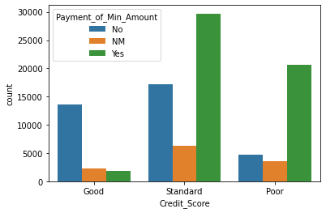

```python
sns.countplot(x='Credit_Score',hue='Payment_of_Min_Amount',data=df)
plt.show()
```

H0: There is no association b/w Payment_of_Min_Amount and Credit_Score

H1: There is an association b/w Payment_of_Min_Amount and Credit_Score

```python
df=pd.crosstab(df.Payment_of_Min_Amount,df.Credit_Score)
df
```

| Credit_Score Payment_of_Min_Amount | Good | Poor | Standard |
| --- | --- | --- | --- |
| NM | 2245 | 3518 | 6241 |
| No | 13671 | 4772 | 17209 |
| Yes | 1912 | 20705 | 29703 |

```python
st.chi2_contingency(df)
```

```
Chi2ContingencyResult(statistic=19622.40762946832, pvalue=0.0, dof=4, expected_freq=array([[ 2140.58686085,  3481.39533488,  6382.01780427],
       [ 6357.56437545, 10339.77894695, 18954.6566776 ],
       [ 9329.8487637 , 15173.82571817, 27816.32551812]]))
```

```python
# chi square critical value
st.chi2.isf(0.05,4)
```

```
9.487729036781158
```

INFERENCE: Since p value reject H0.

```
Hence we conclude that There is an association b/w Payment_of_Min_Amount andCredit_Score.

So impact the Payment_of_Min_Amount customer credit score Good or standard or poor.
```

1. To verify the Payment_Behaviour of the the customer and credit score influence by the customer standard or poor or good.

```python
df = pd.read_csv(r"C:\Users\User\Desktop\Credit_data - Copy.csv")
df
```

|  | ID | Customer_ID | Month | Name | Age | SSN | Occupation | Annual_Income | Monthly_Inhand_Salary | Num_Bank_Accounts | ... | Credit_Mix | Outstanding_Debt | Credit_Utilization_Ratio | Credit_History_Age | Payment_of_Min_Amount | Total_EMI_per_month | Amount_invested_monthly | Payment_Behaviour | Monthly_Balance | Credit_Score |
| --- | --- | --- | --- | --- | --- | --- | --- | --- | --- | --- | --- | --- | --- | --- | --- | --- | --- | --- | --- | --- | --- |
| 0 | 5634 | 3392 | 1 | Aaron Maashoh | 23 | 821000265 | Scientist | 19114.12 | 1824.843333 | 3 | ... | _ | 809.98 | 26.822620 | 182 | No | 49.574949 | 80.415295 | High_spent_Small_value_payments | 312.494089 | Good |
| 1 | 5635 | 3392 | 2 | Aaron Maashoh | 23 | 821000265 | Scientist | 19114.12 | 1824.843333 | 3 | ... | Good | 809.98 | 31.944960 | 183 | No | 49.574949 | 118.280222 | Low_spent_Large_value_payments | 284.629163 | Good |
| 2 | 5636 | 3392 | 3 | Aaron Maashoh | 23 | 821000265 | Scientist | 19114.12 | 1824.843333 | 3 | ... | Good | 809.98 | 28.609352 | 184 | No | 49.574949 | 81.699521 | Low_spent_Medium_value_payments | 331.209863 | Good |
| 3 | 5637 | 3392 | 4 | Aaron Maashoh | 23 | 821000265 | Scientist | 19114.12 | 1824.843333 | 3 | ... | Good | 809.98 | 31.377862 | 185 | No | 49.574949 | 199.458074 | Low_spent_Small_value_payments | 223.451310 | Good |
| 4 | 5638 | 3392 | 5 | Aaron Maashoh | 23 | 821000265 | Scientist | 19114.12 | 1824.843333 | 3 | ... | Good | 809.98 | 24.797347 | 186 | No | 49.574949 | 41.420153 | High_spent_Medium_value_payments | 341.489231 | Good |
| ... | ... | ... | ... | ... | ... | ... | ... | ... | ... | ... | ... | ... | ... | ... | ... | ... | ... | ... | ... | ... | ... |
| 99971 | 155625 | 37932 | 4 | Nicks | 25 | 78735990 | Mechanic | 39628.99 | 3359.415833 | 4 | ... | _ | 502.38 | 34.663572 | 229 | No | 35.104023 | 60.971333 | High_spent_Large_value_payments | 0.000000 | Poor |
| 99972 | 155626 | 37932 | 5 | Nicks | 25 | 78735990 | Mechanic | 39628.99 | 3359.415833 | 4 | ... | _ | 502.38 | 40.565631 | 230 | No | 35.104023 | 54.185950 | High_spent_Medium_value_payments | 0.000000 | Poor |
| 99973 | 155627 | 37932 | 6 | Nicks | 25 | 78735990 | Mechanic | 39628.99 | 3359.415833 | 4 | ... | Good | 502.38 | 41.255522 | 231 | No | 35.104023 | 24.028477 | High_spent_Large_value_payments | 0.000000 | Poor |
| 99974 | 155628 | 37932 | 7 | Nicks | 25 | 78735990 | Mechanic | 39628.99 | 3359.415833 | 4 | ... | Good | 502.38 | 33.638208 | 232 | No | 35.104023 | 251.672582 | Low_spent_Large_value_payments | 0.000000 | Standard |
| 99975 | 155629 | 37932 | 8 | Nicks | 25 | 78735990 | Mechanic | 39628.99 | 3359.415833 | 4 | ... | Good | 502.38 | 34.192463 | 233 | No | 35.104023 | 167.163865 | !@9#%8 | 0.000000 | Poor |

99976 rows × 28 columns

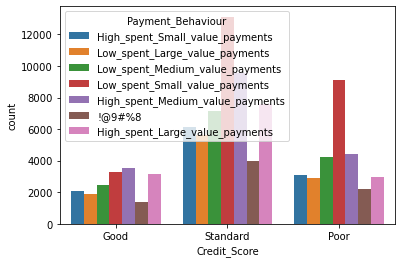

```python
sns.countplot(x='Credit_Score',hue='Payment_Behaviour',data=df)
plt.show()
```

H0: There is no association b/wPayment_Behaviour and Credit_Score

H1: There is an association b/w Payment_Behaviour and Credit_Score